# IODS course project

Paula Vauhkonen

# Introduction to Open Data Science - Course Project

# About the project

This is a PhD course organized by Helsinki University. The project is about getting advanced skills on open data analysis with R.

*Link to my gitHub repository: https://github.com/norppakeitto/IODS-project*

# Paula’s thoughts about…

## the course

I was really glad to find out about this doctoral course provided by Helsinki University. If I recall correctly, this was the result of the great work of the doctoral office and their kind (daily) emails promoting available and upcoming courses.

I am a third year doctoral student and very much into statistics. Despite my colleagues who hate it. Because of my enthusiasm, I took this course even though I constantly struggle to manage with scheduling my studies and working (as an MD). I also have kids I should pay some attention to. I have, however, promised to buy a dog for them once my PhD is finished so I’m not in any hurry here, haha.

I enjoy the opportunity to study things online (whenever I have some free time!) and this course seems REALLY well organized in that regard. So thanks in advance. I hope I manage to get this first week’s assignment done in time, I hate receiving zero points. I’m also sorry for the students that have the dishonor to review my output this week as it may not be very glamorous. My apologies.

I expect to learn new and foremost **faster** and more efficient ways to use R. I was also surprised to hear about automated reports - that sounds fantastic (I think my supervisors would agree).

## the R for Health Data Science book and the Exercise Set 1

All the materials provided in the moodle environment are easy to read and greatly written! I guess taking this course now (not earlier, before any “real life statistical needs”) is more beneficial for me than if I had participated earlier – even though now as I’m going through the course material, I realize I would have saved several hours of work had I known these things earlier. But it’s always better late than never, right?

As I have worked with R before, the first chapters in the RHDS book sounded familiar. However, I learned that search engines prefer “older” scripts over new ones, building the results upon the inverted pyramid of information, I quess. This is good to know. I quess R programming language will evolve in time like any “human” language! In a couple of thousand years, nobody understands any “pipes”… Brouching through the book and excercise set 1 I already came across answers (=script) for some issues I have had previously working with R. For example, how to handle missing data (NAs) in R properly. This almost brought tears to my weary eyes. So, this truly is a “crash course”!

Getting started with R Markdown was executed so sneakily I didn’t ever realize I started using it. Untill I did, and then started wondering if the package for R markdown was to be downloaded first..?

```r
date()
```

```
## [1] "Tue Dec 12 09:39:09 2023"
```

# Assignment 2

### Dataset description

The dataset used in this assignment (lrn14) is retrieved from a larger dataset of “international survey of Approaches to Learning” -study (learning2014), belonging to research project ASSIST 2014 by Kimmo Vehkalahti.

The original dataset includes the points the students (n=183) participating in the course “Introduction to Social Statistics” in fall 2014 (in Finnish) received in the course exam, and several variables derived from survey questions that determine the students’ attitude towards statistics (based on SATS -questionnary), approaches and study skills (based on ASSIST-questionnary). Background variables include age and gender. More information about the original dataset is available at https://www.mv.helsinki.fi/home/kvehkala/JYTmooc/JYTOPKYS3-meta.txt.

The original data has many questions that measure the same *dimension*, that have been transformed to combination variables in the lrn14 dataset. These represent the mean values of all questions that measure deep, surface and strategic learning. Furthermore, the student’s attitude towards statistics has been originally measured as a sum variable of ten Likert scaled (1-5) questions, and the lrn14 dataset includes the mean value of these. Finally, students that have not attended the course examp (points = 0) have been excluded.

To get started, the dataset is loaded to R using the `read.table` -function:

```r
lrn14 <- read.table("https://raw.githubusercontent.com/KimmoVehkalahti/Helsinki-Open-Data-Science/master/datasets/learning2014.txt", sep=",", header=TRUE) # The separator is a comma "," and the file includes a header
```

Then dataset’s dimensions and structure can be assessed using `dim()`and `str()`:

```r
dim(lrn14)
```

```
## [1] 166   7
```

```r
str(lrn14)
```

```
## 'data.frame':    166 obs. of  7 variables:
##  $ gender  : chr  "F" "M" "F" "M" ...
##  $ age     : int  53 55 49 53 49 38 50 37 37 42 ...
##  $ attitude: num  3.7 3.1 2.5 3.5 3.7 3.8 3.5 2.9 3.8 2.1 ...
##  $ deep    : num  3.58 2.92 3.5 3.5 3.67 ...
##  $ stra    : num  3.38 2.75 3.62 3.12 3.62 ...
##  $ surf    : num  2.58 3.17 2.25 2.25 2.83 ...
##  $ points  : int  25 12 24 10 22 21 21 31 24 26 ...
```

The dataset has 166 rows and 7 columns (variables), including gender, age, attitude, deep, stra, surf and points.

### Graphical overview of the data

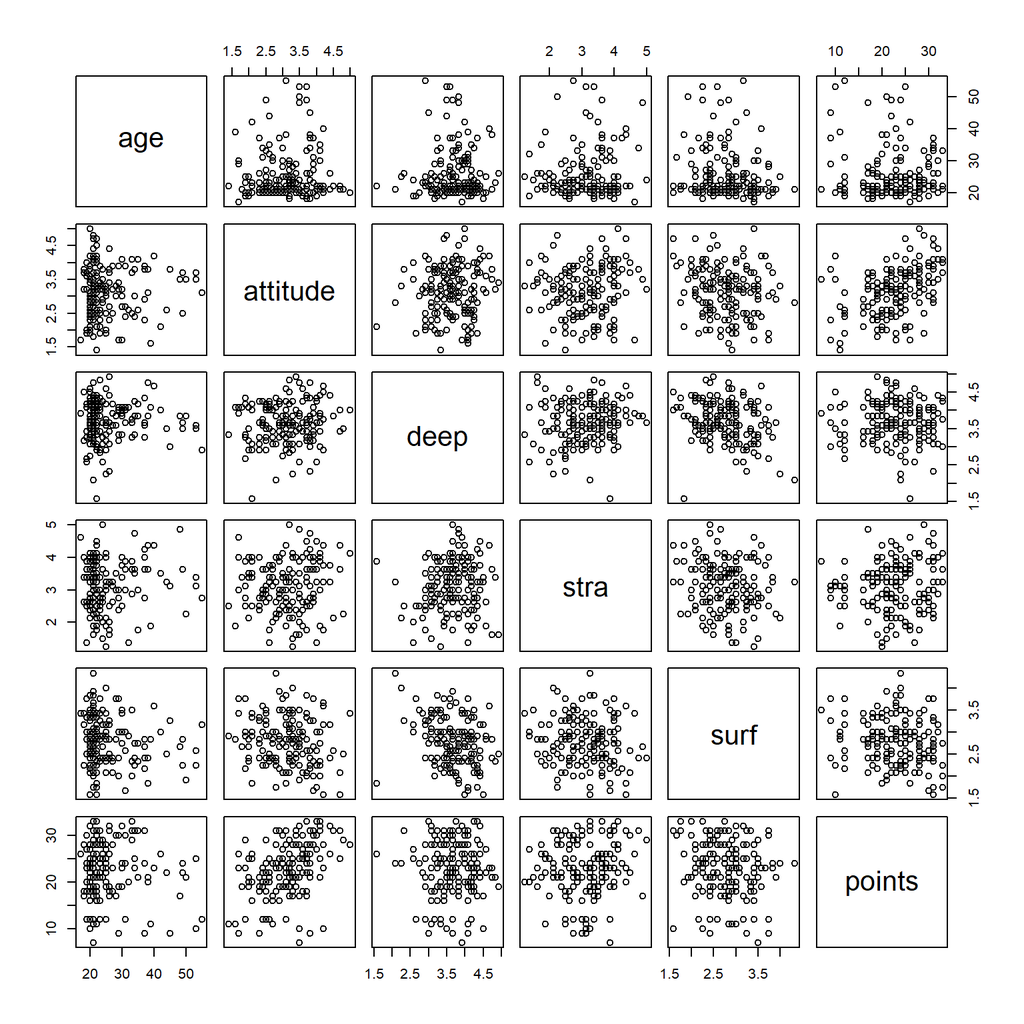

```r
# Access the GGally and ggplot2 libraries

library(ggplot2)
library(GGally)
# A scatter plot matrix of the variables
# [-1] excludes the first column (gender); this needs to be excluded since the `pairs` works only with numerical variables
pairs(lrn14[-1])
```

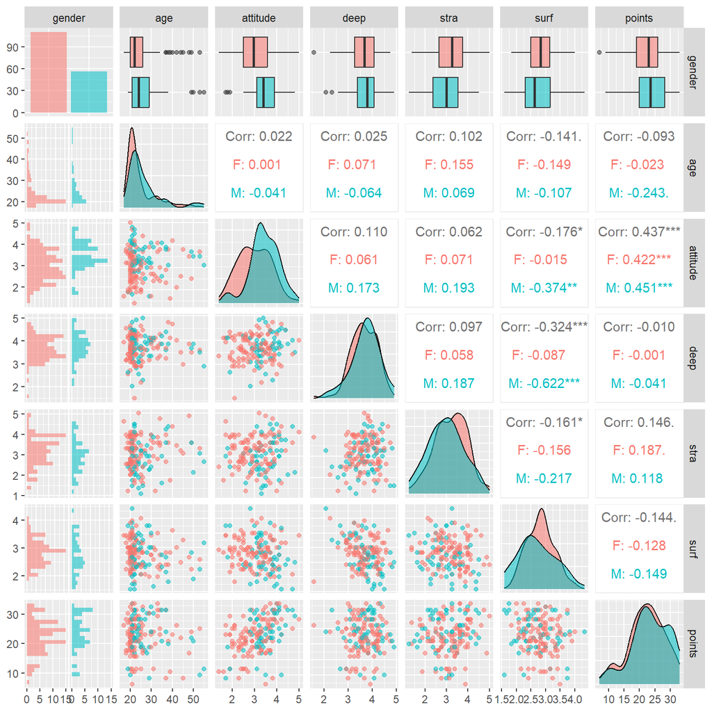

```r
# A more advanced plot matrix can be produced with ggpairs()
p <- ggpairs(lrn14, mapping = aes(col=gender, alpha = 0.3), lower = list(combo = wrap("facethist", bins = 20)))

# Print the matrix
p
```

The age distribution is quite similar between the two genders; majority of the students are in their early 20´s.

Based on the plots and correlation coefficient, there seems to be statistically significant positive correlation between the students’ attitude and exam points (in both genders) and negative correlation between the deep and surface learning skills of male students.

### Creating a regression model

Regression is a way to establish the existence and strength of the relationship between two or more variables. For this purpose, we first need to the choose the target variable, e.g. the variable the value of which is of most interest. This variable is called the dependent or outcome variable. The behavior of this variable can then perhaps be predicted using one or more independent variables in the dataset. Now we aim to create a regression model that predicts the (future) students’ exam points.

Based on the distributions observed previously, a liner model (where the relationship between two variables is linear) seems reasonable to start with, and the three most promising explanatory variables for such a regression model would be the variables attitude, stra and surf. Let’s create a linear model using these variables:

```r
# fit a linear model
my_model <- lm(points ~ attitude + stra + surf, data = lrn14)

# print out a summary of the model

summary(my_model)
```

```
##
## Call:
## lm(formula = points ~ attitude + stra + surf, data = lrn14)
##
## Residuals:
##      Min       1Q   Median       3Q      Max
## -17.1550  -3.4346   0.5156   3.6401  10.8952
##
## Coefficients:
##             Estimate Std. Error t value Pr(>|t|)
## (Intercept)  11.0171     3.6837   2.991  0.00322 **
## attitude      3.3952     0.5741   5.913 1.93e-08 ***
## stra          0.8531     0.5416   1.575  0.11716
## surf         -0.5861     0.8014  -0.731  0.46563
## ---
## Signif. codes:  0 '***' 0.001 '**' 0.01 '*' 0.05 '.' 0.1 ' ' 1
##
## Residual standard error: 5.296 on 162 degrees of freedom
## Multiple R-squared:  0.2074, Adjusted R-squared:  0.1927
## F-statistic: 14.13 on 3 and 162 DF,  p-value: 3.156e-08
```

The model summary gives us first the “fivenum” of the residuals, that is the difference between observed and “predicted” values in the model. Since some predictions fall behind, these are negative, and vice versa. The distribution of these residuals can be evaluated from looking at these values, but a graphical output will be explored a bit later.

Then there are the model coefficients. These describe the mathematical relationship between the outcome variable (points) and each independent variable. The p-values (Pr) are the calculated statistical significances for each relationship.

The residual standard error is the average deviation between the true values and predicted values in the model. In this case, this would be 5.3 points. Underneath this there is Multiple R-squared that means, how much of the variation in the true points can be explained by the variation in the beforementioned explanatory variables and this is around 21 %. The adjusted R-squared gives us a reference to which another model can be compared to: if adding a certain variable to the model makes it better, then this would increase.

Perhaps we should try and remove the variables that are not statistically significant for the predictability of the model.

```r
# fit a linear model
my_model2 <- lm(points ~ attitude, data = lrn14)

# print out a summary of the model

summary(my_model2)
```

```
##
## Call:
## lm(formula = points ~ attitude, data = lrn14)
##
## Residuals:
##      Min       1Q   Median       3Q      Max
## -16.9763  -3.2119   0.4339   4.1534  10.6645
##
## Coefficients:
##             Estimate Std. Error t value Pr(>|t|)
## (Intercept)  11.6372     1.8303   6.358 1.95e-09 ***
## attitude      3.5255     0.5674   6.214 4.12e-09 ***
## ---
## Signif. codes:  0 '***' 0.001 '**' 0.01 '*' 0.05 '.' 0.1 ' ' 1
##
## Residual standard error: 5.32 on 164 degrees of freedom
## Multiple R-squared:  0.1906, Adjusted R-squared:  0.1856
## F-statistic: 38.61 on 1 and 164 DF,  p-value: 4.119e-09
```

This model is not, however, any better, since the predictive ability (Multiple R-squared) is still only around 19 %. Let’s plot the corresponding regression line:

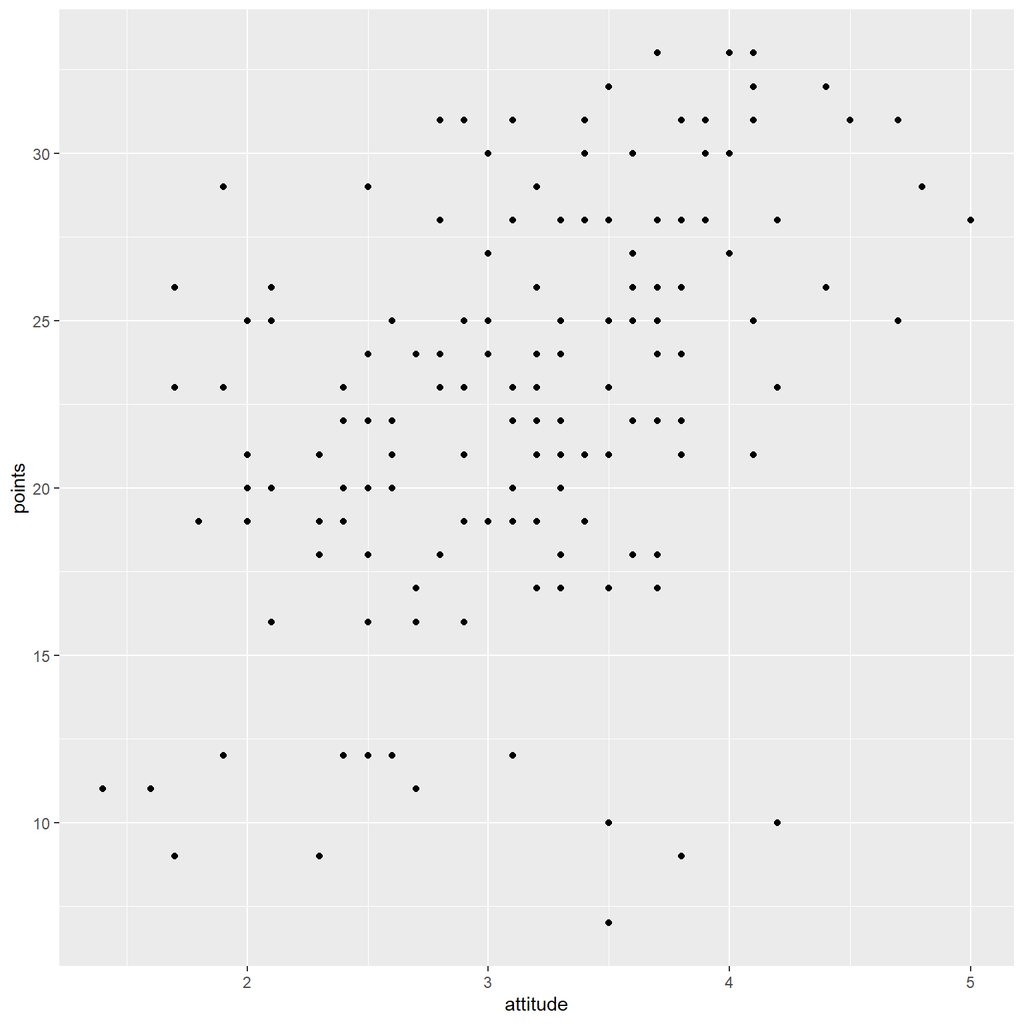

```r
library(ggplot2)

p1 <- ggplot(lrn14, aes(x = attitude, y = points))

# define the visualization type (points)
p2 <- p1 + geom_point()

# draw the plot
p2
```

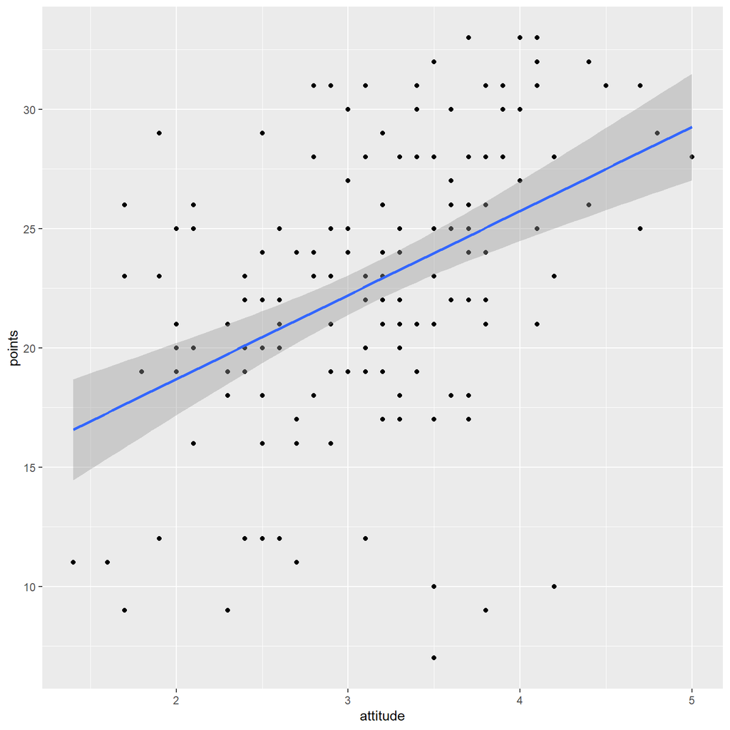

```r
# add a regression line
p3 <- p2 + geom_smooth(method = "lm")

p3
```

This shows there are some very low points across attitude values, explaining the poor fit.

### Diagnostic plots

Diagnostic plots are necessary in order to evaluate that the four assumptions of a linear model fulfill. The assumptions are:

1. Linear relationship between the predictor variable(s) and outcome (if it is not linear, than a linear model most likely doesn’t fit very well);
2. Independence of residuals, (that is, the residuals of the sample are not dependent on each other);
3. Normal distribution of residuals (reflecting their linearity); and
4. Equal variance of residuals (there is no greater variance in residuals of low or high points)

Diagnostic plots can be used to determine (eyeball) the validity of assumption in this case with Residuals vs Fitted values, Normal QQ-plot and Residuals vs Leverage -plots.

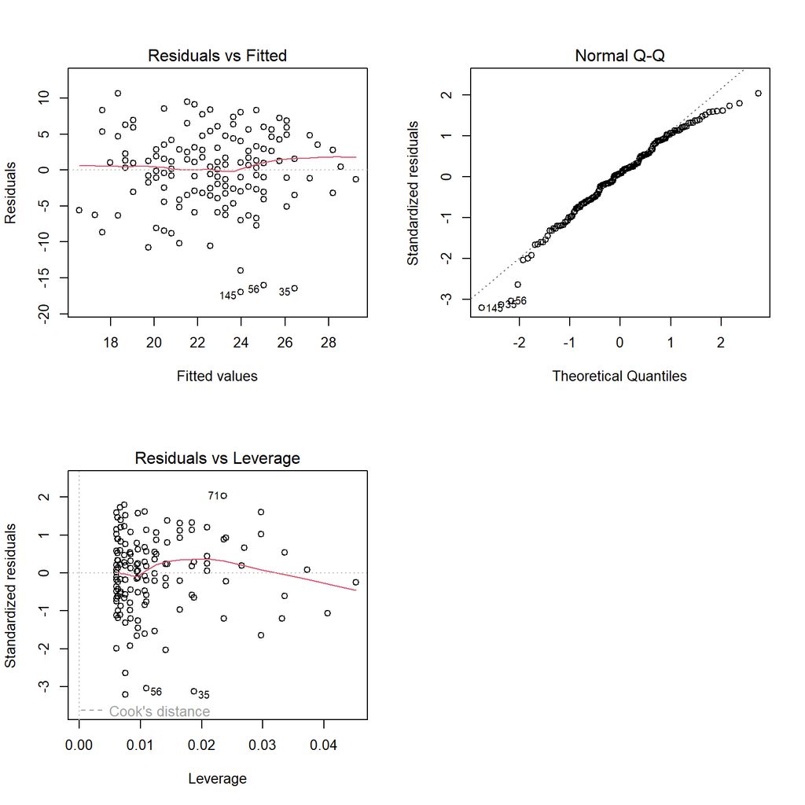

```r
# par(mfrow = c(2,2)) will place the following 4 graphics to the same plot

par(mfrow = c(2,2))

# We use the "plot()" function and specifically choose plots 1, 2 and 5 using the argument `which`. You can check the help page of plotting an lm object by typing `?plot.lm` or `help(plot.lm)` to the R console.

plot(my_model2, which = c(1,2,5))
```

The residuals seem to be quite normally distributed around zero, as seen in Residuals vs Fitted -plot. However, the Q-Q plot is worrysome since there are residuals that fall off the straight line (that would imply normal distribution). The same can be observed whilst looking at the Residuals vs Leverage -plot. Based on these diagnostic plots, there are some “outliers” in the sample. Removing these datapoints (students) from the sample would probably give a linear model more accuracy, or, the model needs to be further improved.

```r
date()
```

```
## [1] "Tue Dec 12 09:39:21 2023"
```

# Assignment 3

### Dataset description

The analysis dataset used in this assignment is based on “Student Performance Data”, available at the UCI Machine Learning Repository and kindly shared with us by Paulo Cortez.

The Student Performance Data includes *two* datasets regarding student performance in secondary education of two Portuguese schools, in two distinct subjects: mathematics and portuguese language. In addition, several background variables, such as age, sex, geopraphical and family history, are included. The “Student Performance Data” dataset and metadata are available [here](https://archive.ics.uci.edu/ml/datasets/Student+Performance).

For this assigment, data is unified from these two datasets via several background variables. Thus only students who answered the questionnaire in both math and portuguese classes are kept in our analysis dataset. Duplicated data has been removed by keeping the first entry for character variables. In case of numerical variables, it has been replaced with the mean.

```r
library(readr)
alc <- read_csv("https://raw.githubusercontent.com/KimmoVehkalahti/Helsinki-Open-Data-Science/master/datasets/alc.csv", show_col_types=F)

# Print out all column names
colnames(alc)
```

```
##  [1] "school"     "sex"        "age"        "address"    "famsize"
##  [6] "Pstatus"    "Medu"       "Fedu"       "Mjob"       "Fjob"
## [11] "reason"     "guardian"   "traveltime" "studytime"  "schoolsup"
## [16] "famsup"     "activities" "nursery"    "higher"     "internet"
## [21] "romantic"   "famrel"     "freetime"   "goout"      "Dalc"
## [26] "Walc"       "health"     "failures"   "paid"       "absences"
## [31] "G1"         "G2"         "G3"         "alc_use"    "high_use"
```

### Data analysis

The purpose of this weeks analysis is to study the relationships between high/low alcohol consumption and some of the other variables in the data. Since the outcome variable is binary, we shall use logistic regression with binomial (Bernoulli) distribution. Basically, we will be comparing the observed relationships in the model to the odds of a coin toss.

To do this, we first choose 4 interesting variables in the data. Let’s start by drawing a bar plot of each variable to get a better conseption of the variables and their distribution.

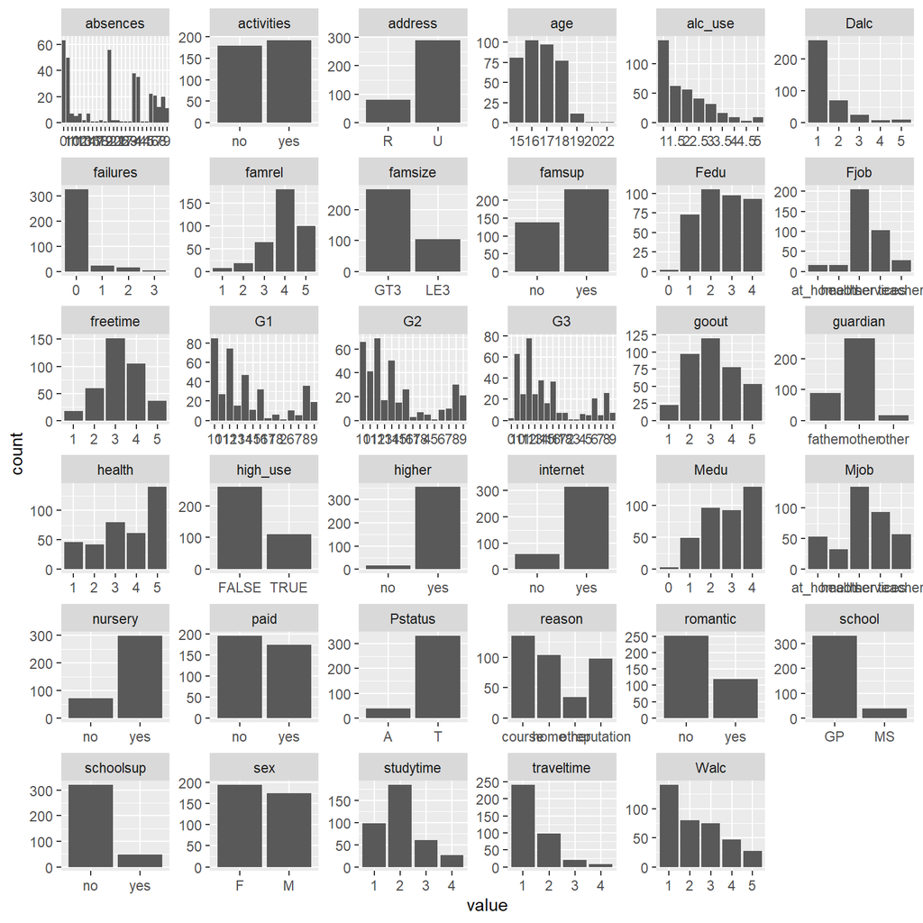

```r
library(tidyr); library(dplyr); library(ggplot2)
gather(alc) %>% ggplot(aes(value)) + facet_wrap("key", scales = "free") +
  geom_bar()
```

Regarding important background variables; sex usually represents a covariate, so it probably should be included in the model.

```r
library(dplyr); library(ggplot2)

# Summary statistics by group

alc %>% group_by(sex, high_use) %>% summarise(count = n())
```

[output not shown]

```
## # A tibble: 4 × 3
## # Groups:   sex [2]
##   sex   high_use count
##   <chr> <lgl>    <int>
## 1 F     FALSE      154
## 2 F     TRUE        41
## 3 M     FALSE      105
## 4 M     TRUE        70
```

```r
p1 <- table(alc$sex, alc$high_use)
prop.table(p1)
```

```
##
##         FALSE      TRUE
##   F 0.4162162 0.1108108
##   M 0.2837838 0.1891892
```

There seems to be higher alcohol consumption among males than females, so 1. sex. Another important backgroud variable might be age (2.), as perhaps the youngest students may not be allowed to purchase alcohol themselves.

Regarding the other variables, alcohol consumption might - based on previous research data and personal experience - affect grades (3.), cause more absences (4.) and failures in exams (5.). These students may also go out more, as alcohol is often consumed while partying (6.). High alcohol consumtion might also deteriorate health (6.).

Let’s plot these variables against high_use, separating females and males. Since the grade has three repetative measures / one individual (G1, G2 and G3), we will only include one of these, the final exam (G3).

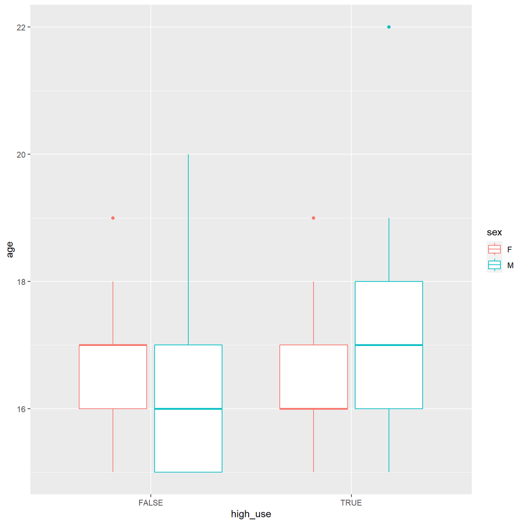

```r
library(tidyr); library(dplyr); library(ggplot2)

g1 <- ggplot(alc, aes(x = high_use, y = age, col=sex))
g1 + geom_boxplot() + ylab("age")
```

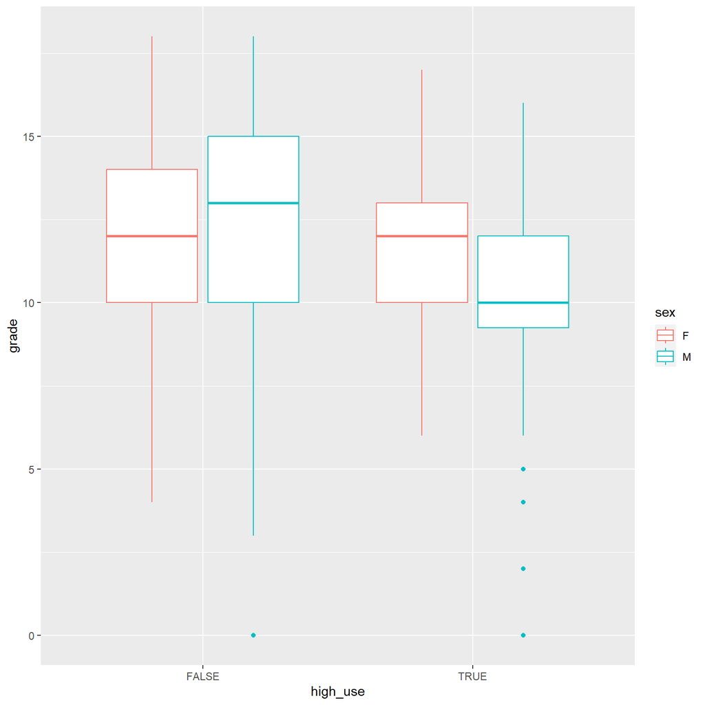

```r
g2 <- ggplot(alc, aes(x = high_use, y = G3, col=sex))
g2 + geom_boxplot() + ylab("grade")
```

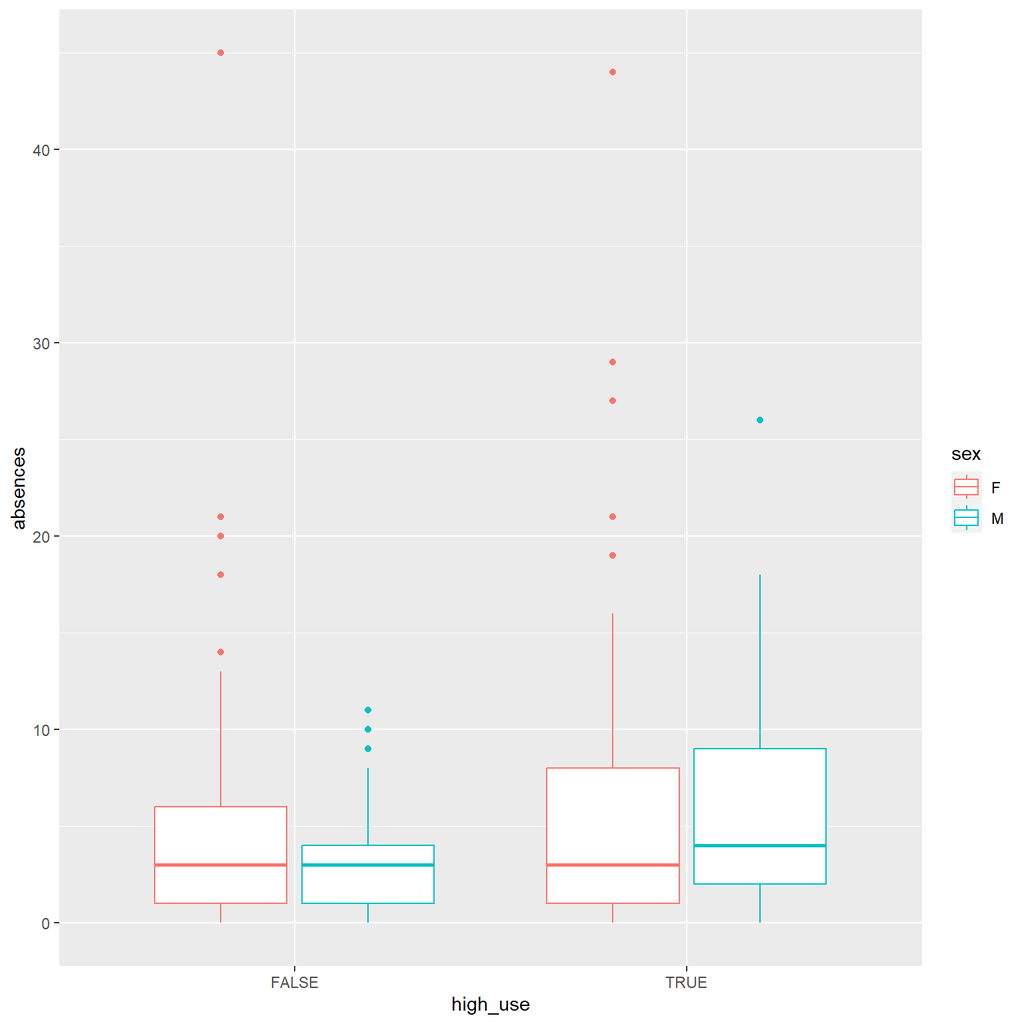

```r
g3 <- ggplot(alc, aes(x = high_use, y = absences, col=sex))
g3 + geom_boxplot() + ylab("absences")
```

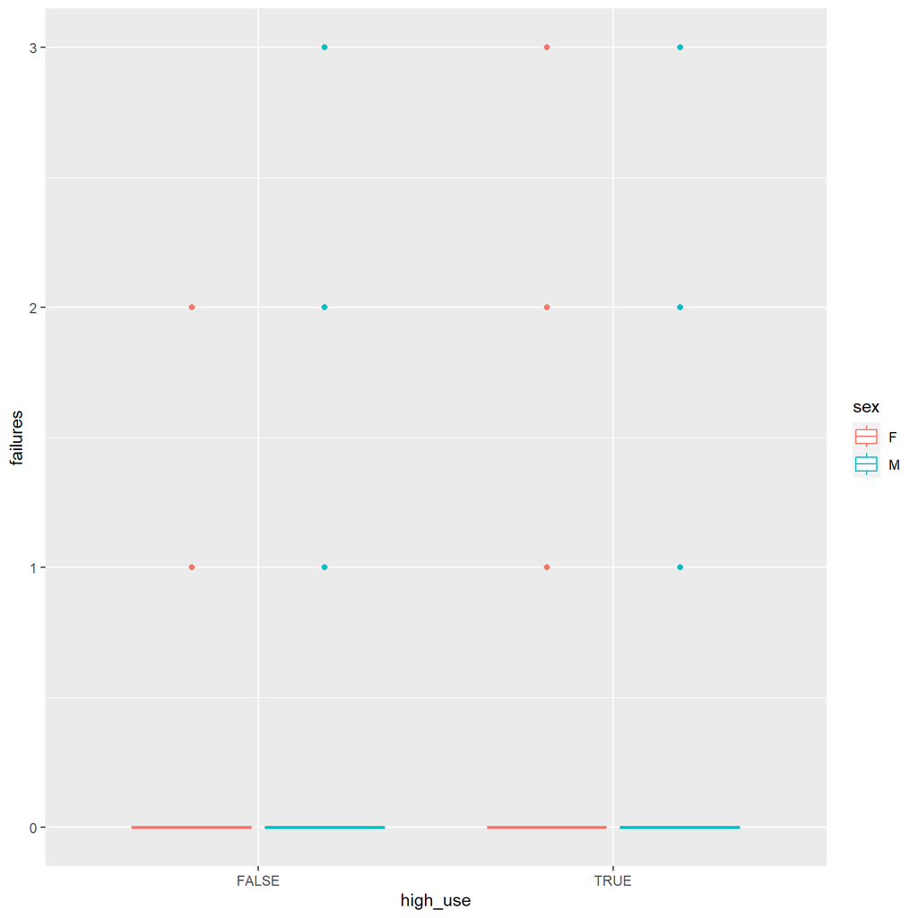

```r
g4 <- ggplot(alc, aes(x = high_use, y = failures, col=sex))
g4 + geom_boxplot() + ylab("failures")
```

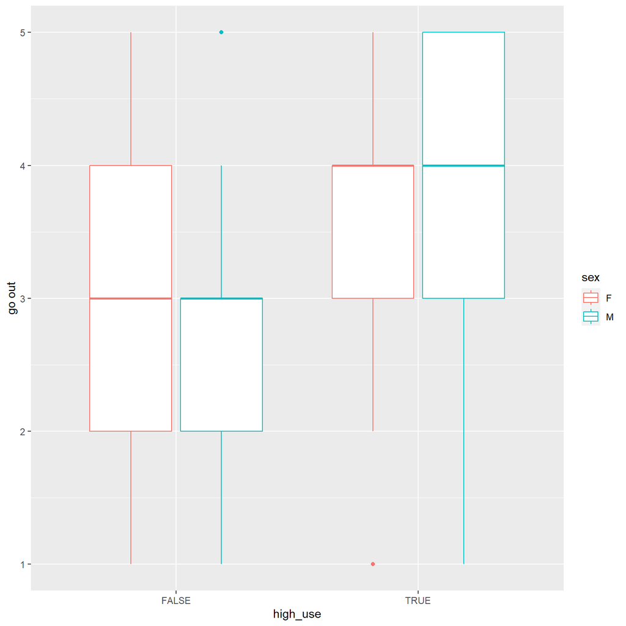

```r
g5 <- ggplot(alc, aes(x = high_use, y = goout, col=sex))
g5 + geom_boxplot() + ylab("go out")
```

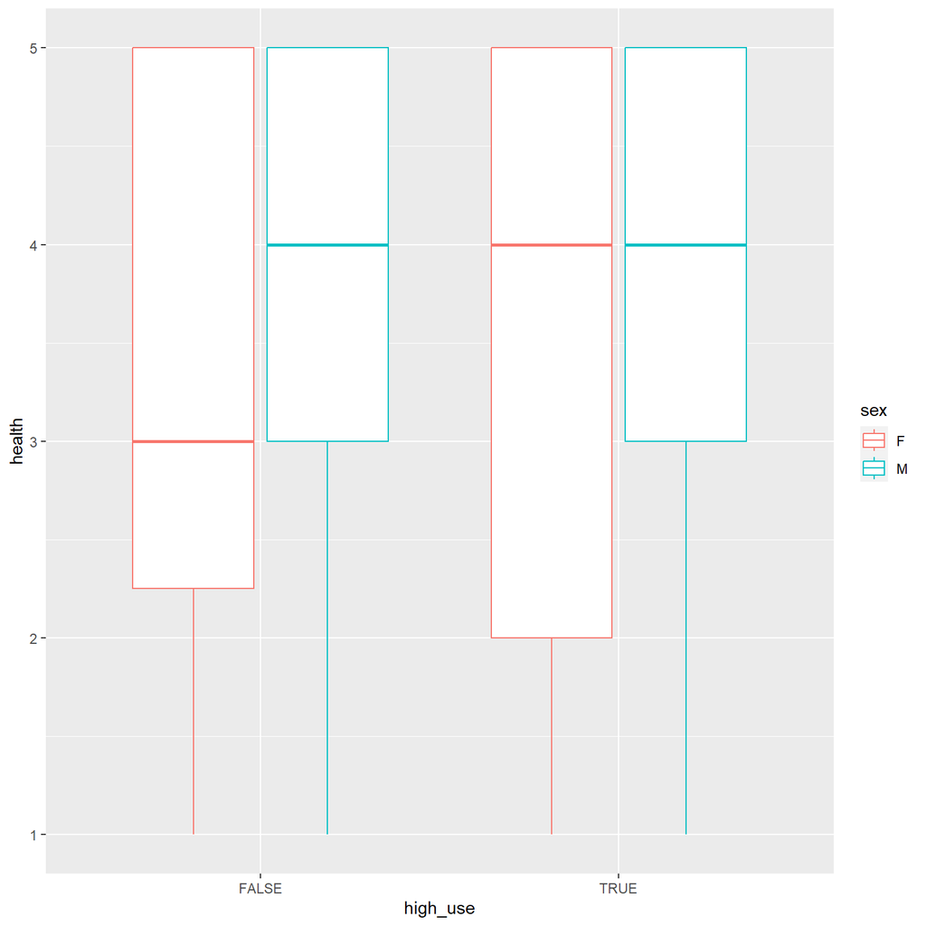

```r
g6 <- ggplot(alc, aes(x = high_use, y = health, col=sex))
g6 + geom_boxplot() + ylab("health")
```

The median age of male students with high alcohol consumption is higher than of those with low alcohol consumption, and the opposite is true for females. However, the outlier student that is 22 years old within male high alcohol consumer group may distort the distribution. The overall age distribution is also quite narrow (majority of the students are about the same age) which may weaken the variable’s predictive ability.

Male students with high alcohol consumption seem to have lower grades (again, there are outliers), and increased absences. There also seems to be more going out among high alcohol consumers, regardless of sex. All of these variables thus seem promising for the model.

Surprisingly, female students with high alcohol consumption report better state of health than those with low alcohol consumption! We could include this variable in the model, but the pre-assumption here would suggest the opposite, so the results gained might not be trustworthy.

Regarding failures, majority of the cases in the dataset have passed their exams (median = 0), so the boxplot is therefore not very informative. We’ll have to try it out.

Let’s start with failures + absences + sex + G3 (model 1).

### Logistic regression

```r
m1 <- glm(high_use ~ failures + absences + sex + G3, data = alc, family = "binomial")
summary(m1)
```

```
##
## Call:
## glm(formula = high_use ~ failures + absences + sex + G3, family = "binomial",
##     data = alc)
##
## Deviance Residuals:
##     Min       1Q   Median       3Q      Max
## -2.1561  -0.8429  -0.5872   1.0033   2.1393
##
## Coefficients:
##             Estimate Std. Error z value Pr(>|z|)
## (Intercept) -1.38733    0.51617  -2.688  0.00719 **
## failures     0.50382    0.22018   2.288  0.02213 *
## absences     0.09058    0.02322   3.901 9.56e-05 ***
## sexM         1.00870    0.24798   4.068 4.75e-05 ***
## G3          -0.04671    0.03948  -1.183  0.23671
## ---
## Signif. codes:  0 '***' 0.001 '**' 0.01 '*' 0.05 '.' 0.1 ' ' 1
##
## (Dispersion parameter for binomial family taken to be 1)
##
##     Null deviance: 452.04  on 369  degrees of freedom
## Residual deviance: 405.59  on 365  degrees of freedom
## AIC: 415.59
##
## Number of Fisher Scoring iterations: 4
```

The deviance tells us how well our model fits the data, in terms of error. The coefficient estimates are the *logarithmic odds* of change in the response variable, in respect to one unit change in the explanatory variable, keeping that the other variables stay put (conditionally on these). Logartimic link function is necessary here to provide equal scale to the response variable that varies from 0-100% (or 0-1) and the explanatory variables (with also numerical values included).

The interpretation regarding sex here is a bit different: one unit change in this variable means transition from one category to other; from female (0) to male (1).

The odds can be tabulated with exp(Estimate) = propability/(1-probability) = ODDS. These can be interpreted as *odds ratios between one unit change vs. no change* in the corresponding explanatory variable.

Failures are significant; and absences and sex highly significant predictors of the probability of being judged to have high alcohol consumption in this model. Grades are not.

There is also AIC = Akaike information criterion, that tells us how economic the model is. That is, how good is the predictive ability when considering the number of variables included, as too many might cause overfitting.

Next, let’s change grades to “go out”.

```r
m2 <- glm(high_use ~ failures + absences + sex + goout, data = alc, family = "binomial")
summary(m2)
```

```
##
## Call:
## glm(formula = high_use ~ failures + absences + sex + goout, family = "binomial",
##     data = alc)
##
## Deviance Residuals:
##     Min       1Q   Median       3Q      Max
## -2.1521  -0.7929  -0.5317   0.7412   2.3706
##
## Coefficients:
##             Estimate Std. Error z value Pr(>|z|)
## (Intercept) -4.14389    0.47881  -8.654  < 2e-16 ***
## failures     0.48932    0.23073   2.121 0.033938 *
## absences     0.08246    0.02266   3.639 0.000274 ***
## sexM         0.97989    0.26156   3.746 0.000179 ***
## goout        0.69801    0.12093   5.772 7.83e-09 ***
## ---
## Signif. codes:  0 '***' 0.001 '**' 0.01 '*' 0.05 '.' 0.1 ' ' 1
##
## (Dispersion parameter for binomial family taken to be 1)
##
##     Null deviance: 452.04  on 369  degrees of freedom
## Residual deviance: 369.50  on 365  degrees of freedom
## AIC: 379.5
##
## Number of Fisher Scoring iterations: 4
```

With model 2, AIC is lower (which is good!) and all the variables are statistically significant. Then we should check for multicollinearity:

```r
library(car)
vif(m2)
```

```
## failures absences      sex    goout
## 1.004386 1.019900 1.024599 1.005110
```

VIF is low for all the variables, so no worries in that regard. Then, let’s calculate the corresponding ODDS ratios and confidence intervals (95%):

```r
OR <- coef(m2) %>% exp
CI <- confint(m2) %>% exp
cbind(OR, CI)
```

```
##                     OR       2.5 %     97.5 %
## (Intercept) 0.01586098 0.005950831 0.03905075
## failures    1.63121360 1.042981792 2.59042892
## absences    1.08595465 1.039999394 1.13814475
## sexM        2.66415000 1.605059602 4.48576247
## goout       2.00975350 1.594527456 2.56461657
```

The odds ratio for having high alcohol consumption is 1.6 if failures increase by one (unit); 1.1 if absences increase by one (unit); 2.7 if the student is a male (compared to being female); and 2.0 if going out increases by one (unit). These are conditional of the other variable values staying similar.

If the 95% CI would cross the value “1”, it would mean that the true odds ratio may be 1/1 = no difference in the odds per one unit change in the particular explanatory variable.

The pre-stated hypothesis for a relationship between failures, absences, going out (and male gender, as an important background variable) and high alcohol consumption seems valid.

### Predicting exercise

```r
library(dplyr)
# predict the probability of high_use
probabilities <- predict(m2, type = "response")
alc <- mutate(alc, probability = probabilities)
alc <- mutate(alc, prediction = probability>0.5)
table(high_use = alc$high_use, prediction = alc$prediction)
```

```
##         prediction
## high_use FALSE TRUE
##    FALSE   243   16
##    TRUE     61   50
```

Graphic visualizing both the actual values and the predictions:

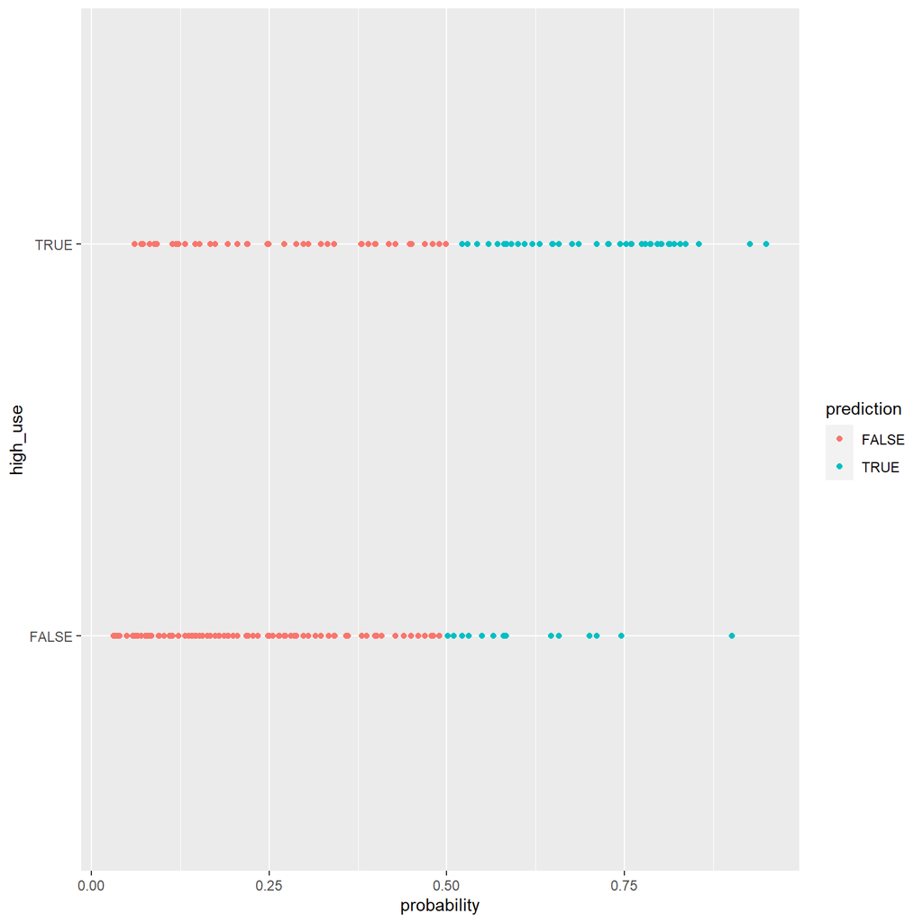

```r
library(dplyr); library(ggplot2)

g <- ggplot(alc, aes(x = probability, y = high_use, col = prediction))
g + geom_point()
```

This visualizes that the model performs better on low alcohol users than among high alcohol users.

Training error using mean prediction error:

```r
loss_func <- function(class, prob) {
  n_wrong <- abs(class - prob) > 0.5
  mean(n_wrong)
}

lf <- loss_func(class = alc$high_use, prob = alc$probability)
1-lf
```

```
## [1] 0.7918919
```

79 % of the model’s predictions would be correct (21 % would be incorrect). If I was to toss a coin (for a thousand times) guessing “heads” every time, I would be right in 50 % of cases. So the model exceeds pure guess.

### Cross validation

Let’s perform 10-fold cross-validation on the model and compare the test set performance (measured as smaller prediction error) to the model introduced in the Exercise Set (which had about 0.26 error).

```r
library(boot)
cv <- cv.glm(data = alc, cost = loss_func, glmfit = m2, K = 10)

# average number of wrong predictions in the cross validation
cv$delta[1]
```

```
## [1] 0.2081081
```

This model’s test set performance exceeds the performance of the Exercise set model.

```r
date()
```

```
## [1] "Tue Dec 12 09:39:31 2023"
```

# Assignment 4

### Dataset description

The dataset used in this exercise (Boston data) is available within the MASS R-package.

```r
library(MASS)
data("Boston")
str(Boston)
```

```
## 'data.frame':    506 obs. of  14 variables:
##  $ crim   : num  0.00632 0.02731 0.02729 0.03237 0.06905 ...
##  $ zn     : num  18 0 0 0 0 0 12.5 12.5 12.5 12.5 ...
##  $ indus  : num  2.31 7.07 7.07 2.18 2.18 2.18 7.87 7.87 7.87 7.87 ...
##  $ chas   : int  0 0 0 0 0 0 0 0 0 0 ...
##  $ nox    : num  0.538 0.469 0.469 0.458 0.458 0.458 0.524 0.524 0.524 0.524 ...
##  $ rm     : num  6.58 6.42 7.18 7 7.15 ...
##  $ age    : num  65.2 78.9 61.1 45.8 54.2 58.7 66.6 96.1 100 85.9 ...
##  $ dis    : num  4.09 4.97 4.97 6.06 6.06 ...
##  $ rad    : int  1 2 2 3 3 3 5 5 5 5 ...
##  $ tax    : num  296 242 242 222 222 222 311 311 311 311 ...
##  $ ptratio: num  15.3 17.8 17.8 18.7 18.7 18.7 15.2 15.2 15.2 15.2 ...
##  $ black  : num  397 397 393 395 397 ...
##  $ lstat  : num  4.98 9.14 4.03 2.94 5.33 ...
##  $ medv   : num  24 21.6 34.7 33.4 36.2 28.7 22.9 27.1 16.5 18.9 ...
```

```r
dim(Boston)
```

```
## [1] 506  14
```

The data has 506 observations and 14 variables. All the variables are numerical; variables “chas” and “rad” are integers. More information about the variables in available [here](https://stat.ethz.ch/R-manual/R-devel/library/MASS/html/Boston.html).

Variable summaries and graphical overview of the data

```r
summary(Boston)
```

```
##       crim                zn             indus            chas
##  Min.   : 0.00632   Min.   :  0.00   Min.   : 0.46   Min.   :0.00000
##  1st Qu.: 0.08205   1st Qu.:  0.00   1st Qu.: 5.19   1st Qu.:0.00000
##  Median : 0.25651   Median :  0.00   Median : 9.69   Median :0.00000
##  Mean   : 3.61352   Mean   : 11.36   Mean   :11.14   Mean   :0.06917
##  3rd Qu.: 3.67708   3rd Qu.: 12.50   3rd Qu.:18.10   3rd Qu.:0.00000
##  Max.   :88.97620   Max.   :100.00   Max.   :27.74   Max.   :1.00000
##       nox               rm             age              dis
##  Min.   :0.3850   Min.   :3.561   Min.   :  2.90   Min.   : 1.130
##  1st Qu.:0.4490   1st Qu.:5.886   1st Qu.: 45.02   1st Qu.: 2.100
##  Median :0.5380   Median :6.208   Median : 77.50   Median : 3.207
##  Mean   :0.5547   Mean   :6.285   Mean   : 68.57   Mean   : 3.795
##  3rd Qu.:0.6240   3rd Qu.:6.623   3rd Qu.: 94.08   3rd Qu.: 5.188
##  Max.   :0.8710   Max.   :8.780   Max.   :100.00   Max.   :12.127
##       rad              tax           ptratio          black
##  Min.   : 1.000   Min.   :187.0   Min.   :12.60   Min.   :  0.32
##  1st Qu.: 4.000   1st Qu.:279.0   1st Qu.:17.40   1st Qu.:375.38
##  Median : 5.000   Median :330.0   Median :19.05   Median :391.44
##  Mean   : 9.549   Mean   :408.2   Mean   :18.46   Mean   :356.67
##  3rd Qu.:24.000   3rd Qu.:666.0   3rd Qu.:20.20   3rd Qu.:396.23
##  Max.   :24.000   Max.   :711.0   Max.   :22.00   Max.   :396.90
##      lstat            medv
##  Min.   : 1.73   Min.   : 5.00
##  1st Qu.: 6.95   1st Qu.:17.02
##  Median :11.36   Median :21.20
##  Mean   :12.65   Mean   :22.53
##  3rd Qu.:16.95   3rd Qu.:25.00
##  Max.   :37.97   Max.   :50.00
```

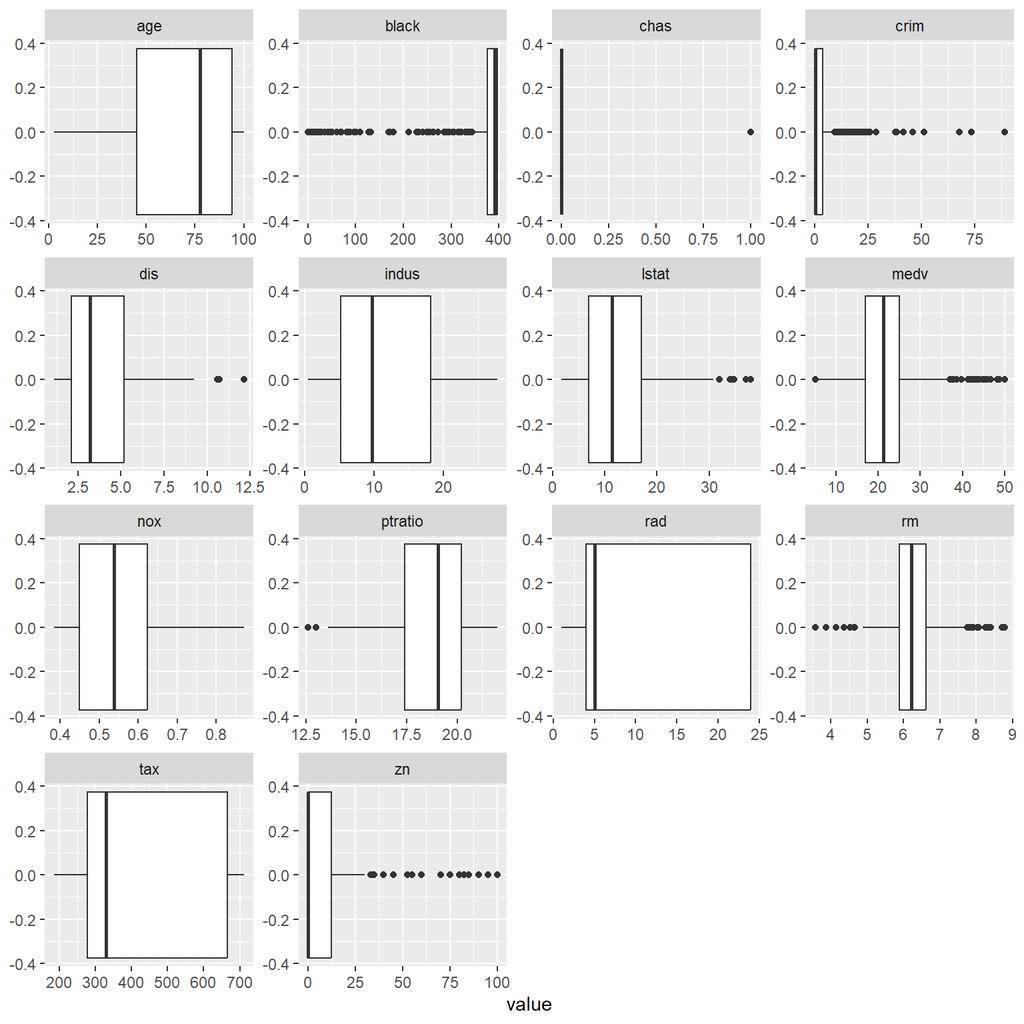

```r
library(tidyr); library(dplyr); library(ggplot2)
gather(Boston) %>% ggplot(aes(value)) + facet_wrap("key", scales = "free") +
  geom_boxplot()
```

The variable values are all positive, and of very different magnitude. For example, “chas” values are between 0-1 and tax values between 187-711. Almost all of the distributions are skewed.

Correlation matrix

```r
library(MASS)
library(tidyr)
library(corrplot)
cor_matrix <- cor(Boston)
cor_matrix %>% round(2)
```

```
##          crim    zn indus  chas   nox    rm   age   dis   rad   tax ptratio
## crim     1.00 -0.20  0.41 -0.06  0.42 -0.22  0.35 -0.38  0.63  0.58    0.29
## zn      -0.20  1.00 -0.53 -0.04 -0.52  0.31 -0.57  0.66 -0.31 -0.31   -0.39
## indus    0.41 -0.53  1.00  0.06  0.76 -0.39  0.64 -0.71  0.60  0.72    0.38
## chas    -0.06 -0.04  0.06  1.00  0.09  0.09  0.09 -0.10 -0.01 -0.04   -0.12
## nox      0.42 -0.52  0.76  0.09  1.00 -0.30  0.73 -0.77  0.61  0.67    0.19
## rm      -0.22  0.31 -0.39  0.09 -0.30  1.00 -0.24  0.21 -0.21 -0.29   -0.36
## age      0.35 -0.57  0.64  0.09  0.73 -0.24  1.00 -0.75  0.46  0.51    0.26
## dis     -0.38  0.66 -0.71 -0.10 -0.77  0.21 -0.75  1.00 -0.49 -0.53   -0.23
## rad      0.63 -0.31  0.60 -0.01  0.61 -0.21  0.46 -0.49  1.00  0.91    0.46
## tax      0.58 -0.31  0.72 -0.04  0.67 -0.29  0.51 -0.53  0.91  1.00    0.46
## ptratio  0.29 -0.39  0.38 -0.12  0.19 -0.36  0.26 -0.23  0.46  0.46    1.00
## black   -0.39  0.18 -0.36  0.05 -0.38  0.13 -0.27  0.29 -0.44 -0.44   -0.18
## lstat    0.46 -0.41  0.60 -0.05  0.59 -0.61  0.60 -0.50  0.49  0.54    0.37
## medv    -0.39  0.36 -0.48  0.18 -0.43  0.70 -0.38  0.25 -0.38 -0.47   -0.51
##         black lstat  medv
## crim    -0.39  0.46 -0.39
## zn       0.18 -0.41  0.36
## indus   -0.36  0.60 -0.48
## chas     0.05 -0.05  0.18
## nox     -0.38  0.59 -0.43
## rm       0.13 -0.61  0.70
## age     -0.27  0.60 -0.38
## dis      0.29 -0.50  0.25
## rad     -0.44  0.49 -0.38
## tax     -0.44  0.54 -0.47
## ptratio -0.18  0.37 -0.51
## black    1.00 -0.37  0.33
## lstat   -0.37  1.00 -0.74
## medv     0.33 -0.74  1.00
```

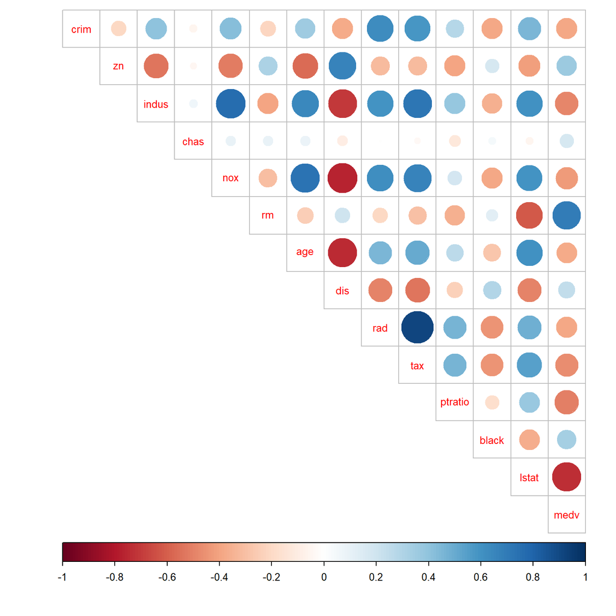

```r
corrplot(cor_matrix, method="circle", type = "upper", cl.pos = "b", tl.pos = "d", tl.cex = 0.8)
```

The correlation plot demonstrates that there is high positive correlation between the variables nox and indus; nox and age; indus and tax; rad and tax. Also, there is high negative correlation between dis and indus; dis and nox; dis and age; and medv and lstat.

### Dataset scaling with standardization

```r
boston_scaled <- scale(Boston)
summary(boston_scaled)
```

```
##       crim                 zn               indus              chas
##  Min.   :-0.419367   Min.   :-0.48724   Min.   :-1.5563   Min.   :-0.2723
##  1st Qu.:-0.410563   1st Qu.:-0.48724   1st Qu.:-0.8668   1st Qu.:-0.2723
##  Median :-0.390280   Median :-0.48724   Median :-0.2109   Median :-0.2723
##  Mean   : 0.000000   Mean   : 0.00000   Mean   : 0.0000   Mean   : 0.0000
##  3rd Qu.: 0.007389   3rd Qu.: 0.04872   3rd Qu.: 1.0150   3rd Qu.:-0.2723
##  Max.   : 9.924110   Max.   : 3.80047   Max.   : 2.4202   Max.   : 3.6648
##       nox                rm               age               dis
##  Min.   :-1.4644   Min.   :-3.8764   Min.   :-2.3331   Min.   :-1.2658
##  1st Qu.:-0.9121   1st Qu.:-0.5681   1st Qu.:-0.8366   1st Qu.:-0.8049
##  Median :-0.1441   Median :-0.1084   Median : 0.3171   Median :-0.2790
##  Mean   : 0.0000   Mean   : 0.0000   Mean   : 0.0000   Mean   : 0.0000
##  3rd Qu.: 0.5981   3rd Qu.: 0.4823   3rd Qu.: 0.9059   3rd Qu.: 0.6617
##  Max.   : 2.7296   Max.   : 3.5515   Max.   : 1.1164   Max.   : 3.9566
##       rad               tax             ptratio            black
##  Min.   :-0.9819   Min.   :-1.3127   Min.   :-2.7047   Min.   :-3.9033
##  1st Qu.:-0.6373   1st Qu.:-0.7668   1st Qu.:-0.4876   1st Qu.: 0.2049
##  Median :-0.5225   Median :-0.4642   Median : 0.2746   Median : 0.3808
##  Mean   : 0.0000   Mean   : 0.0000   Mean   : 0.0000   Mean   : 0.0000
##  3rd Qu.: 1.6596   3rd Qu.: 1.5294   3rd Qu.: 0.8058   3rd Qu.: 0.4332
##  Max.   : 1.6596   Max.   : 1.7964   Max.   : 1.6372   Max.   : 0.4406
##      lstat              medv
##  Min.   :-1.5296   Min.   :-1.9063
##  1st Qu.:-0.7986   1st Qu.:-0.5989
##  Median :-0.1811   Median :-0.1449
##  Mean   : 0.0000   Mean   : 0.0000
##  3rd Qu.: 0.6024   3rd Qu.: 0.2683
##  Max.   : 3.5453   Max.   : 2.9865
```

Standardization transforms the data to have zero mean (and a variance of 1). This way variables with large numbers don’t have greater impact on the (future) model.

### Exchanging numerical scaled crime rates with quantile-based categories

```r
data("Boston")
boston_scaled <- as.data.frame(scale(Boston))
boston_scaled$crim <- as.numeric(boston_scaled$crim)

bins <- quantile(boston_scaled$crim)
crime <- cut(boston_scaled$crim, breaks = bins, include.lowest = TRUE, labels=c("low", "med_low", "med_high","high"))

boston_scaled <- dplyr::select(boston_scaled, -crim)
boston_scaled <- data.frame(boston_scaled, crime)
```

### Cross-validation

Dataset is divided into train (80% of data) and test (20% of data) sets. In order to perform the validation, the correct crime classes are removed from test data and saved to an object for later use.

```r
# creating training set
n <- nrow(boston_scaled)
ind <- sample(n,  size = n * 0.8)
train <- boston_scaled[ind,]

# creating test set
test <- boston_scaled[-ind,]

correct_classes <- test$crime
test <- dplyr::select(test, -crime)
```

### Fitting linear discriminant analysis

Linear discriminant analysis is performed on the train data. The target variable here will be the categorical multiclass variable crime rate. All the other variables act as predictor variables. We’ll also draw the LDA (bi)plot with “arrows” that demonstrate the variable vectors.

```r
lda.fit <- lda(crime  ~ ., data = train)

lda.fit
```

```
## Call:
## lda(crime ~ ., data = train)
##
## Prior probabilities of groups:
##       low   med_low  med_high      high
## 0.2400990 0.2450495 0.2623762 0.2524752
##
## Group means:
##                   zn      indus        chas        nox         rm        age
## low       0.96947737 -0.8725131 -0.10997442 -0.8708633  0.4982324 -0.8827756
## med_low  -0.07535982 -0.3024421 -0.03371693 -0.5841070 -0.1126208 -0.3006797
## med_high -0.38854187  0.1679207  0.21052285  0.3697233  0.1375015  0.4054457
## high     -0.48724019  1.0171096 -0.07933396  1.0794094 -0.3971804  0.7950937
##                 dis        rad        tax     ptratio      black       lstat
## low       0.8569818 -0.6835066 -0.7630858 -0.50231858  0.3791689 -0.80749370
## med_low   0.4136131 -0.5433656 -0.5051477 -0.03031698  0.3121223 -0.13756445
## med_high -0.3709497 -0.3859685 -0.2981896 -0.30715210  0.1111981 -0.02029811
## high     -0.8396918  1.6382099  1.5141140  0.78087177 -0.6056460  0.86950542
##                  medv
## low       0.571580396
## med_low  -0.001590121
## med_high  0.202609438
## high     -0.663194951
##
## Coefficients of linear discriminants:
##                 LD1         LD2         LD3
## zn       0.08979071  0.82710310 -0.86560514
## indus   -0.02308971 -0.12517248  0.26485137
## chas    -0.07247328 -0.08271301  0.04919842
## nox      0.38966776 -0.69892262 -1.28234070
## rm      -0.09754652 -0.08117854 -0.18660050
## age      0.26870869 -0.30938754  0.05089051
## dis     -0.12824853 -0.30485255  0.36734688
## rad      2.95563851  1.03790232 -0.03967879
## tax      0.06685419 -0.22544994  0.45966732
## ptratio  0.09964084  0.03413462 -0.11719061
## black   -0.11064597  0.02583415  0.10489054
## lstat    0.19505331 -0.21921977  0.39609704
## medv     0.15558356 -0.41504915 -0.09594418
##
## Proportion of trace:
##    LD1    LD2    LD3
## 0.9468 0.0398 0.0135
```

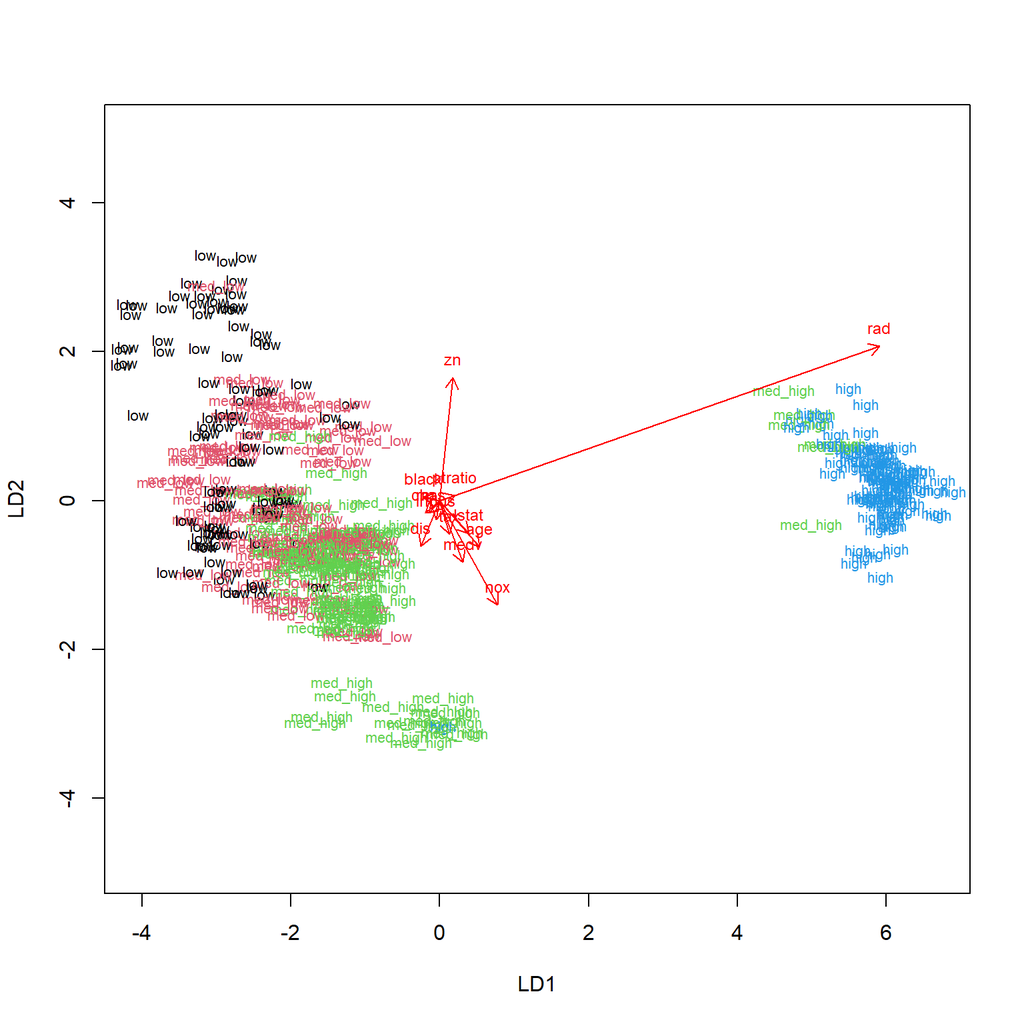

```r
# the function for lda biplot arrows
lda.arrows <- function(x, myscale = 1, arrow_heads = 0.1, color = "red", tex = 0.75, choices = c(1,2)){
  heads <- coef(x)
  graphics::arrows(x0 = 0, y0 = 0,
         x1 = myscale * heads[,choices[1]],
         y1 = myscale * heads[,choices[2]], col=color, length = arrow_heads)
  text(myscale * heads[,choices], labels = row.names(heads),
       cex = tex, col=color, pos=3)
}

# target classes are taken as numeric for plotting purposes
classes <- as.numeric(train$crime)

# plot
plot(lda.fit, dimen = 2, col = classes, pch = classes)
lda.arrows(lda.fit, myscale = 2)
```

### Predicting exercise

We’ll apply the LDA model on the test data set and test how well it works.

```r
# predicting classes with test data
lda.pred <- predict(lda.fit, newdata = test)

# cross tabulation
table(correct = correct_classes, predicted = lda.pred$class)
```

```
##           predicted
## correct    low med_low med_high high
##   low       17      13        0    0
##   med_low    5      16        6    0
##   med_high   1       6       13    0
##   high       0       0        0   25
```

The last official assigment was to

- Reload the Boston dataset and standardize it
- Calculate the distances between the observations
- Run k-means algorithm on the dataset
- Investigate the optimal number of clusters
- Run the algorithm again
- Visualize the clusters and
- Interpret the results.

Euclidean distances using standardized Boston dataset

```r
library(MASS)
data("Boston")
boston_scaled <- scale(Boston)

# euclidean distance matrix
dist_eu <- dist(boston_scaled)
summary(dist_eu)
```

```
##    Min. 1st Qu.  Median    Mean 3rd Qu.    Max.
##  0.1343  3.4625  4.8241  4.9111  6.1863 14.3970
```

The mean euclidean or pythagorean distance is 4.9 (units).

K-MEANS CLUSTERING

We’ll start with three clusters. We’ll set seed for reproducibility of the results.

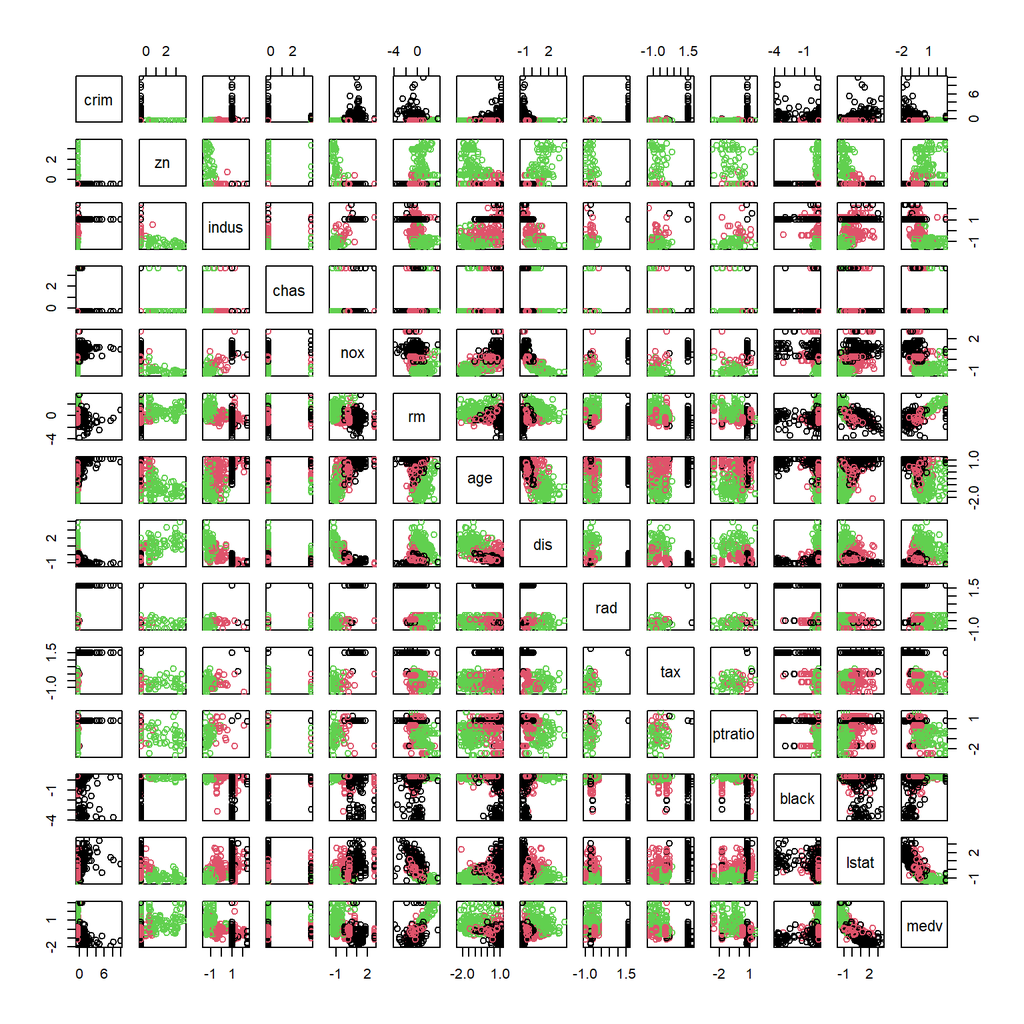

```r
library(MASS)
library(ggplot2)
set.seed(123)
km <- kmeans(boston_scaled, centers = 3)
pairs(boston_scaled, col = km$cluster)
```

Cluster number optimization

Optimization can be done by calculating the TOTAL within cluster sums of squares (twcss) and plotting them against the number of clusters. We’ll assume that the optimal number of clusters will be somewhere between 2-10, so the maximum number of clusters is set to 15.

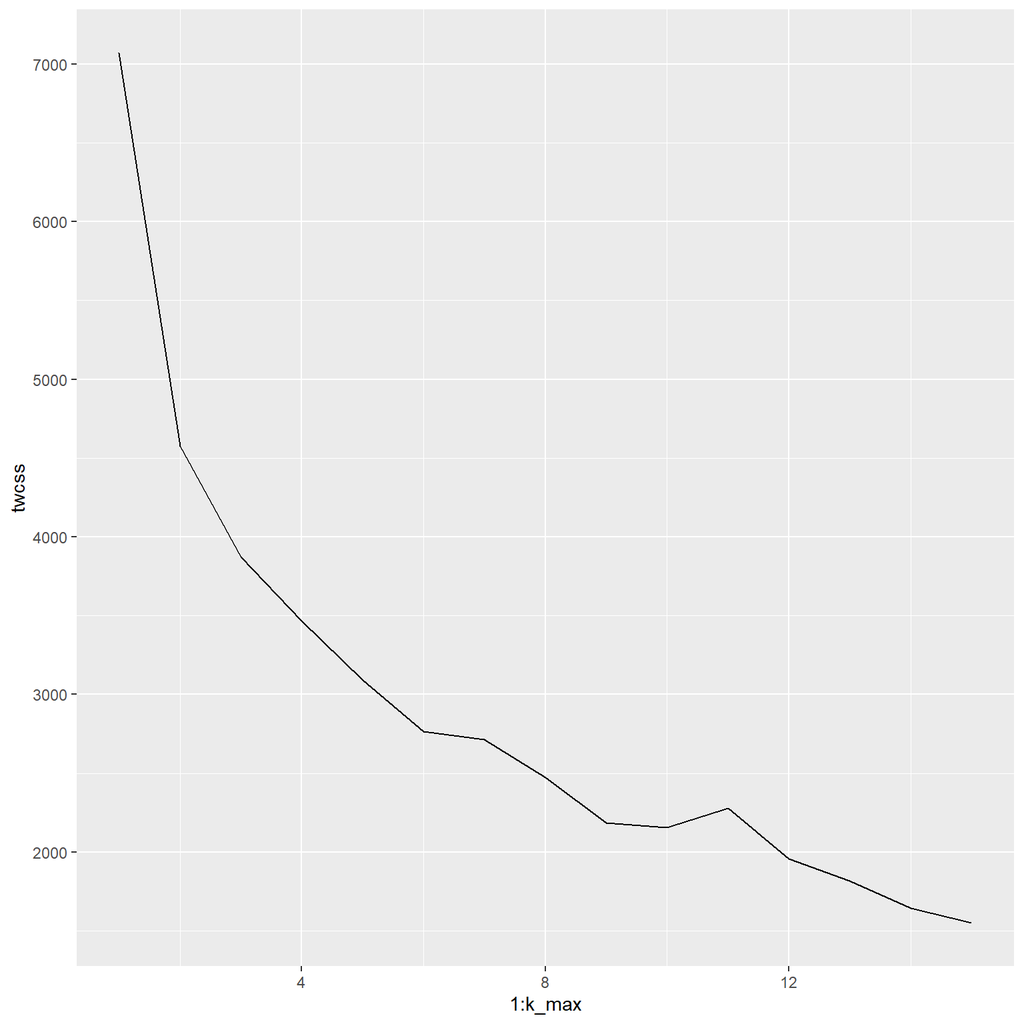

```r
k_max <- 15
twcss <- sapply(1:k_max, function(k){kmeans(boston_scaled, k)$tot.withinss})
qplot(x = 1:k_max, y = twcss, geom = 'line')
```

The wcss drops radically at about 2, indicating that with two clusters, the data within each cluster resembles the cluster center prototypes well. Another feasible choice could be 7 clusters. Of course, adding more clusters would lower the twcss further but having too many clusters makes the model useless. We’ll continue with two clusters.

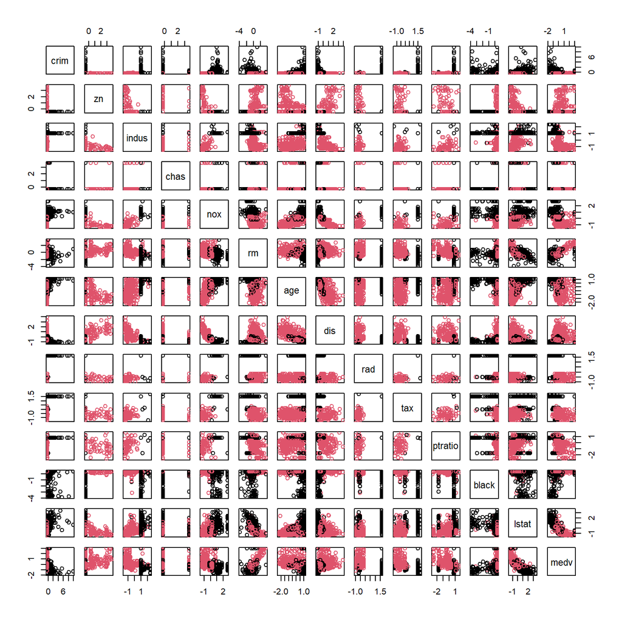

```r
set.seed(123)
km <- kmeans(boston_scaled, centers = 2)
library("ggplot2")
library("GGally")
# plot with clusters
pairs(boston_scaled, col=km$cluster)
```

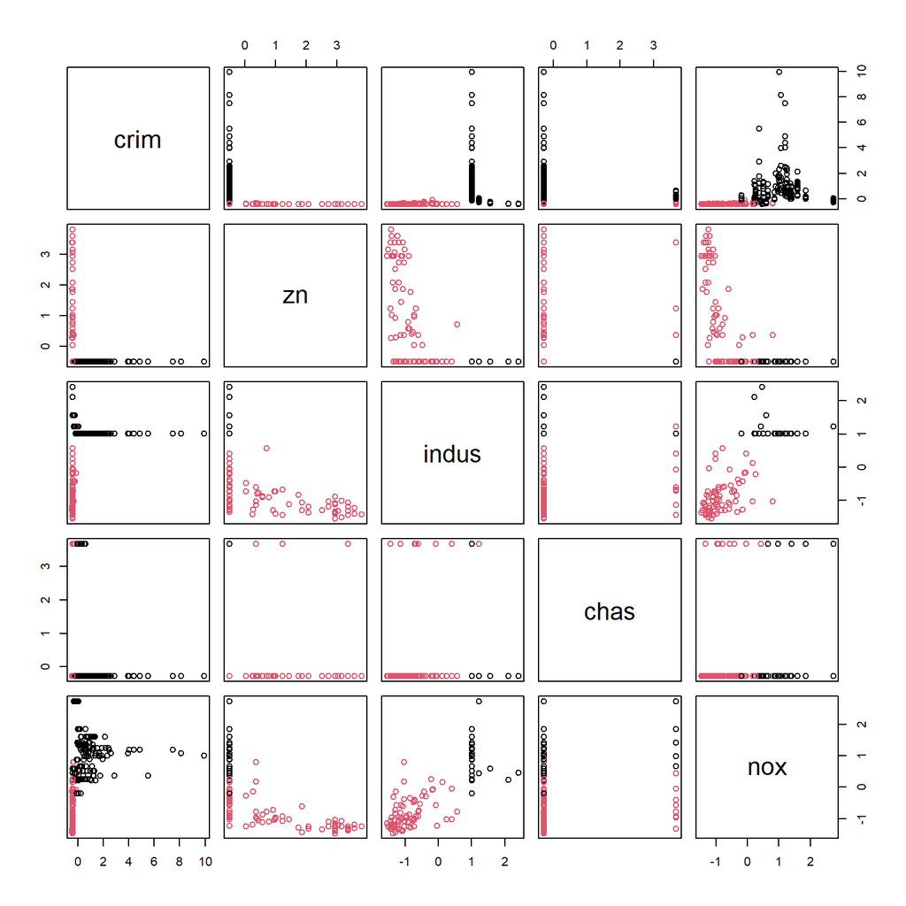

```r
pairs(boston_scaled[,1:5], col=km$cluster)
```

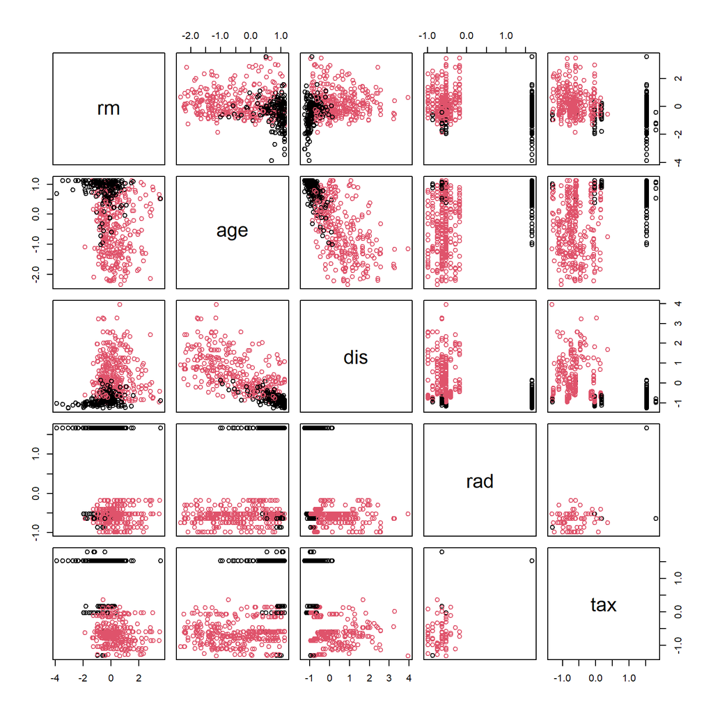

```r
pairs(boston_scaled[,6:10], col=km$cluster)
```

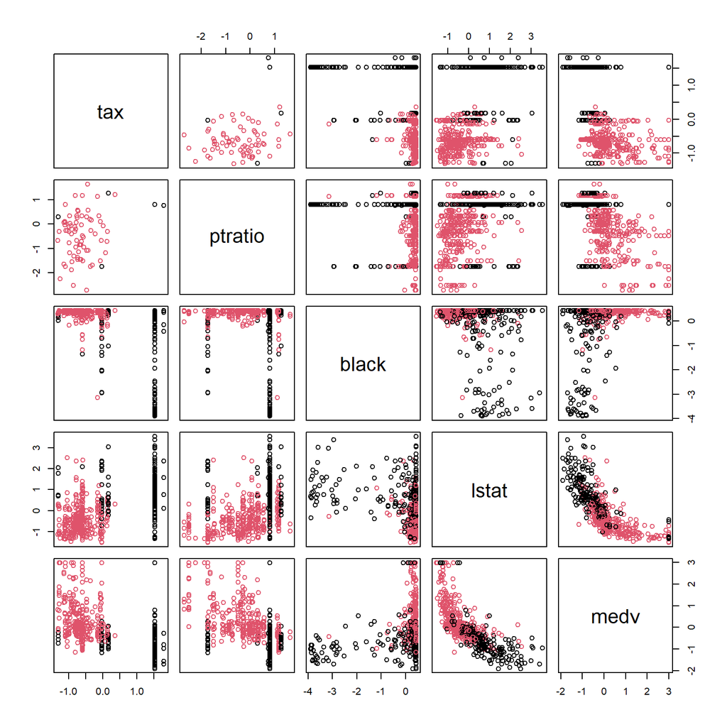

```r
pairs(boston_scaled[,10:14], col=km$cluster)
```

The variable “crim”, “zn” and “indus” seem to have most effect on the clustering results.

```r
date()
```

```
## [1] "Tue Dec 12 09:39:44 2023"
```

```r
fig.dim = c(8, 8)
```

# Assignment 5

### Human dataset

The metadata for the human dataset are available at my GitHub repository *https://github.com/norppakeitto/IODS-project*.

Variable summaries and graphical overview of the human dataset

```r
library(readr)
human <- read_csv("https://raw.githubusercontent.com/KimmoVehkalahti/Helsinki-Open-Data-Science/master/datasets/human2.csv")
# The country names are moved to rownames.
library(tibble)
human_ <- column_to_rownames(human, "Country")
str(human_)
```

```
## 'data.frame':    155 obs. of  8 variables:
##  $ Edu2.FM  : num  1.007 0.997 0.983 0.989 0.969 ...
##  $ Labo.FM  : num  0.891 0.819 0.825 0.884 0.829 ...
##  $ Life.Exp : num  81.6 82.4 83 80.2 81.6 80.9 80.9 79.1 82 81.8 ...
##  $ Edu.Exp  : num  17.5 20.2 15.8 18.7 17.9 16.5 18.6 16.5 15.9 19.2 ...
##  $ GNI      : num  64992 42261 56431 44025 45435 ...
##  $ Mat.Mor  : num  4 6 6 5 6 7 9 28 11 8 ...
##  $ Ado.Birth: num  7.8 12.1 1.9 5.1 6.2 3.8 8.2 31 14.5 25.3 ...
##  $ Parli.F  : num  39.6 30.5 28.5 38 36.9 36.9 19.9 19.4 28.2 31.4 ...
```

```r
summary(human_)
```

```
##     Edu2.FM          Labo.FM          Life.Exp        Edu.Exp
##  Min.   :0.1717   Min.   :0.1857   Min.   :49.00   Min.   : 5.40
##  1st Qu.:0.7264   1st Qu.:0.5984   1st Qu.:66.30   1st Qu.:11.25
##  Median :0.9375   Median :0.7535   Median :74.20   Median :13.50
##  Mean   :0.8529   Mean   :0.7074   Mean   :71.65   Mean   :13.18
##  3rd Qu.:0.9968   3rd Qu.:0.8535   3rd Qu.:77.25   3rd Qu.:15.20
##  Max.   :1.4967   Max.   :1.0380   Max.   :83.50   Max.   :20.20
##       GNI            Mat.Mor         Ado.Birth         Parli.F
##  Min.   :   581   Min.   :   1.0   Min.   :  0.60   Min.   : 0.00
##  1st Qu.:  4198   1st Qu.:  11.5   1st Qu.: 12.65   1st Qu.:12.40
##  Median : 12040   Median :  49.0   Median : 33.60   Median :19.30
##  Mean   : 17628   Mean   : 149.1   Mean   : 47.16   Mean   :20.91
##  3rd Qu.: 24512   3rd Qu.: 190.0   3rd Qu.: 71.95   3rd Qu.:27.95
##  Max.   :123124   Max.   :1100.0   Max.   :204.80   Max.   :57.50
```

All the variables are numerical and have very different magnitude and variation. Let’s examine the intercorrelations with correlation matrix.

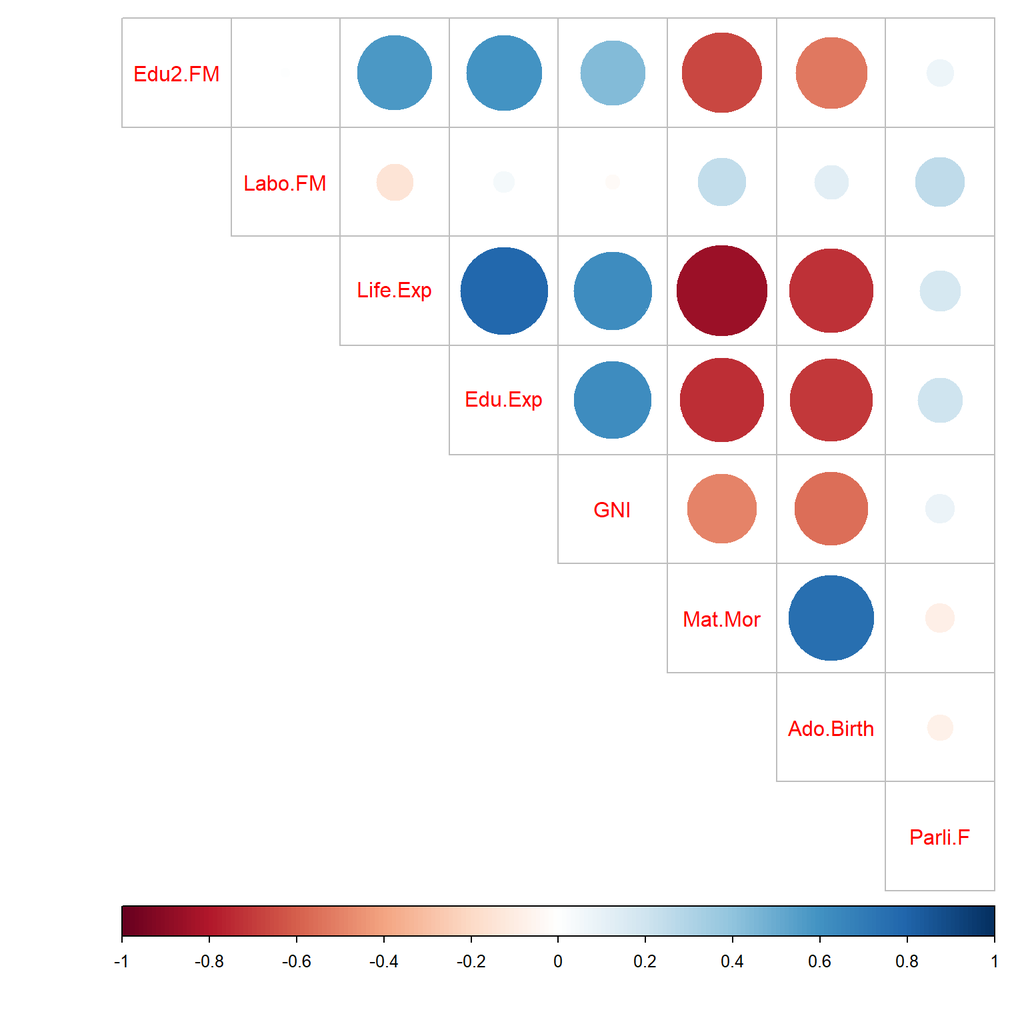

```r
library(corrplot)
cor(human_) %>% corrplot(method="circle", type = "upper", cl.pos = "b", tl.pos = "d", tl.cex = 1.0)
```

There seems to be strong positive correlation with maternal mortality (Mat.Mor) & adolescent birth rate (Ado.Birth); and expected years of schooling (Edu.Exp) & life expectancy at birth (Life.Exp). There is also moderate positive correlation with gross national income per capita (GNI) & life expectancy at birth; GNI & expected years of schooling; life expectancy at birth & female to male ratio with at least secondary education (Edu2.FM); and expected years if schooling & female to male ratio with at least secondary education.

On the other hand, there is strong negative correlation with maternal mortality & life expectancy at birth; maternal mortality & expected years of schooling; maternal mortality & and female to male ratio with at least secondary education; adolescent birth rate & life expectancy at birth; adolescent birth rate & expected years of schooling.

There are also weaker correlations between the other variables; of note, percentage of female representatives in parliament (Parli.F) seems to be very weakly correlated with the other variables (except for female to male ratio in the labour force) and there is near zero correlation between female to male ratio with at least secondary education & Female to male ratio in the labour force.

Principal component analysis (PCA) on the raw (non-standardized) human data. I’ll use the SVD method.

```r
pca_human <- prcomp(human_)
s <- summary(pca_human)
# rounded percentanges of variance captured by each PC
pca_pr <- round(1*s$importance[2, ], digits = 5)
pca_pr
```

```
##    PC1    PC2    PC3    PC4    PC5    PC6    PC7    PC8
## 0.9999 0.0001 0.0000 0.0000 0.0000 0.0000 0.0000 0.0000
```

With non-standardized data, the first principal component already accounts for nearly 100 % of the original data variation.

biplot displaying the observations by the first two principal components

[figure not shown]

```r
pc_lab <- paste0(names(pca_pr), " (", pca_pr, "%)")
biplot(pca_human, cex = c(0.8, 1), col = c("orange", "deeppink2"), xlab = pc_lab[1], ylab = pc_lab[2])
```

Without standardization, GNI with the greatest variance overrules the analysis.

Let’s repeate the PCA with standardized variables.

```r
human_std <- scale(human_)
pca_human2 <- prcomp(human_std)
su <- summary(pca_human2)
pca_pr2 <- round(1*su$importance[2, ], digits = 5)
pca_pr2
```

```
##     PC1     PC2     PC3     PC4     PC5     PC6     PC7     PC8
## 0.53605 0.16237 0.09571 0.07583 0.05477 0.03595 0.02634 0.01298
```

This time the first principal component accounts for 53.6% of the variation, and the second principal component adds another 16.2 %.

biplot displaying the observations by the first two principal components; standardized data

[figure not shown]

```r
pc_lab2 <- paste0(names(pca_pr2), " (", pca_pr2, "%)")
biplot(pca_human2, cex = c(0.8, 1.0), expand=2, col = c("orange", "deeppink2"), xlab = pc_lab2[1], ylab = pc_lab2[2],xlim=c(-0.4, 0.4), ylim=c(-0.4, 0.4))
```

The biplot demonstrates the previously mentioned linear dependencies between the original variables. Maternal mortality and adolescent birth rate are correlated and positively correlated with the first principal component. The arrows point to increasing values in these variables: so, these are both high in Sierra Leone, for example.

Expected years of schooling, life expectancy at birth, female to male ratio with at least secondary education and gross national income per capita are all intercorrelated. These are all negatively correlated with the first principal component. In countries of this direction, maternal mortality and adolescent birth rate are low.

The results imply that in countries with high GNI, people live a long life and especially females are highly educated. If the situation is the opposite, there are teenage pregnancies and maternal mortality is high.

The second principal component seems to mostly explain variation in the percentage of female representatives in parliament and female to male ratio in the labour force, which are somewhat correlated. Since labour force indicates all the members of a particular country who are able to work, then more available labour force naturally may increase female attendance in the parliament, but only to some extent. These variables also seem to be somewhat independent regarding the other variables in the data. There may be countries with high female to male ratio in labour force but also high maternal mortality and adolescent birth rate.

### The tea data

The tea data includes 300 individuals that were asked how they drink tea (18 questions) and what are their product’s perception (12 questions). In addition, some personal details were asked (4 questions).

```r
tea <- read.csv("https://raw.githubusercontent.com/KimmoVehkalahti/Helsinki-Open-Data-Science/master/datasets/tea.csv", stringsAsFactors = TRUE)
str(tea)
```

```
## 'data.frame':    300 obs. of  36 variables:
##  $ breakfast       : Factor w/ 2 levels "breakfast","Not.breakfast": 1 1 2 2 1 2 1 2 1 1 ...
##  $ tea.time        : Factor w/ 2 levels "Not.tea time",..: 1 1 2 1 1 1 2 2 2 1 ...
##  $ evening         : Factor w/ 2 levels "evening","Not.evening": 2 2 1 2 1 2 2 1 2 1 ...
##  $ lunch           : Factor w/ 2 levels "lunch","Not.lunch": 2 2 2 2 2 2 2 2 2 2 ...
##  $ dinner          : Factor w/ 2 levels "dinner","Not.dinner": 2 2 1 1 2 1 2 2 2 2 ...
##  $ always          : Factor w/ 2 levels "always","Not.always": 2 2 2 2 1 2 2 2 2 2 ...
##  $ home            : Factor w/ 2 levels "home","Not.home": 1 1 1 1 1 1 1 1 1 1 ...
##  $ work            : Factor w/ 2 levels "Not.work","work": 1 1 2 1 1 1 1 1 1 1 ...
##  $ tearoom         : Factor w/ 2 levels "Not.tearoom",..: 1 1 1 1 1 1 1 1 1 2 ...
##  $ friends         : Factor w/ 2 levels "friends","Not.friends": 2 2 1 2 2 2 1 2 2 2 ...
##  $ resto           : Factor w/ 2 levels "Not.resto","resto": 1 1 2 1 1 1 1 1 1 1 ...
##  $ pub             : Factor w/ 2 levels "Not.pub","pub": 1 1 1 1 1 1 1 1 1 1 ...
##  $ Tea             : Factor w/ 3 levels "black","Earl Grey",..: 1 1 2 2 2 2 2 1 2 1 ...
##  $ How             : Factor w/ 4 levels "alone","lemon",..: 1 3 1 1 1 1 1 3 3 1 ...
```

[output cut: 22 more lines]

```r
dim(tea)
```

```
## [1] 300  36
```

The data has mostly factor variables; there is only one numerical variable, “age”.

```r
View(tea)
```

The age variable is also available as a factor conversion (age_Q), namely the age quartiles. I’d like to see multiple correspondence analysis including the variables age (quartiles), sex and different meals of the day.

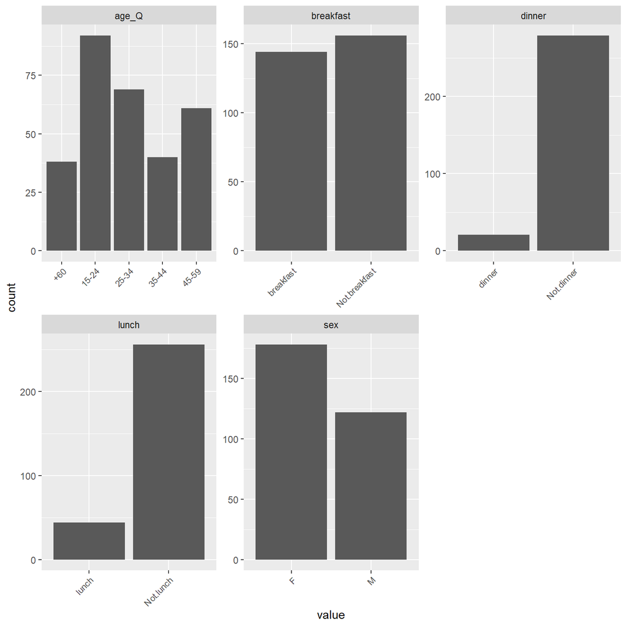

```r
library(dplyr)
library(tidyr)
library(ggplot2)
keep_columns <- c("age_Q", "sex", "breakfast", "lunch", "dinner")
tea_time <- dplyr::select(tea, keep_columns)
pivot_longer(tea_time, cols = everything()) %>%
  ggplot(aes(value)) + facet_wrap("name", scales = "free") + geom_bar() + theme(axis.text.x = element_text(angle = 45, hjust = 1, size = 8))
```

The barplots indicate that the largest age group in the study is 15-24 year old people. Tea is consumed during breakfast by almost 50 % of the respondents, but most don’t have tea during dinner or lunch. Then, a greater proportion of respondents were female.

Multiple Correspondence Analysis (MCA) on the tea data

```r
library(FactoMineR)
```

```r
mca <- MCA(tea_time, graph = FALSE)

summary(mca)
```

```
##
## Call:
## MCA(X = tea_time, graph = FALSE)
##
##
## Eigenvalues
##                        Dim.1   Dim.2   Dim.3   Dim.4   Dim.5   Dim.6   Dim.7
## Variance               0.284   0.235   0.226   0.208   0.196   0.171   0.145
## % of var.             17.734  14.692  14.113  12.994  12.254  10.715   9.064
## Cumulative % of var.  17.734  32.426  46.539  59.533  71.788  82.503  91.567
##                        Dim.8
## Variance               0.135
## % of var.              8.433
## Cumulative % of var. 100.000
##
## Individuals (the 10 first)
##                  Dim.1    ctr   cos2    Dim.2    ctr   cos2    Dim.3    ctr
## 1             |  0.028  0.001  0.000 | -0.429  0.260  0.099 | -0.871  1.120
## 2             | -0.513  0.309  0.221 | -0.058  0.005  0.003 | -0.465  0.320
## 3             |  0.705  0.584  0.131 | -0.570  0.461  0.086 |  0.537  0.426
## 4             |  1.253  1.846  0.434 | -0.314  0.140  0.027 |  0.916  1.238
## 5             | -0.040  0.002  0.001 |  0.120  0.020  0.011 | -0.821  0.995
## 6             |  1.253  1.846  0.434 | -0.314  0.140  0.027 |  0.916  1.238
## 7             |  0.028  0.001  0.000 | -0.429  0.260  0.099 | -0.871  1.120
## 8             | -0.245  0.071  0.036 | -0.964  1.318  0.556 | -0.109  0.018
## 9             |  0.028  0.001  0.000 | -0.429  0.260  0.099 | -0.871  1.120
## 10            |  0.028  0.001  0.000 | -0.429  0.260  0.099 | -0.871  1.120
##                 cos2
## 1              0.408 |
## 2              0.182 |
## 3              0.076 |
## 4              0.232 |
## 5              0.502 |
## 6              0.232 |
## 7              0.408 |
## 8              0.007 |
## 9              0.408 |
## 10             0.408 |
##
## Categories (the 10 first)
```

[output cut: 15 more lines]

```
## 35-44         -10.010 |  -0.882   9.190   0.120  -5.983 |
## 45-59          -1.273 |  -0.764  10.503   0.149  -6.671 |
## F              -3.675 |   0.344   6.207   0.172   7.178 |
## M               3.675 |  -0.501   9.056   0.172  -7.178 |
## breakfast       7.477 |  -0.502  10.697   0.232  -8.333 |
## Not.breakfast  -7.477 |   0.463   9.874   0.232   8.333 |
## lunch          12.344 |   0.493   3.162   0.042   3.537 |
##
## Categorical variables (eta2)
##                 Dim.1 Dim.2 Dim.3
## age_Q         | 0.426 0.424 0.552 |
## sex           | 0.383 0.045 0.172 |
## breakfast     | 0.071 0.187 0.232 |
## lunch         | 0.061 0.510 0.042 |
## dinner        | 0.479 0.009 0.131 |
```

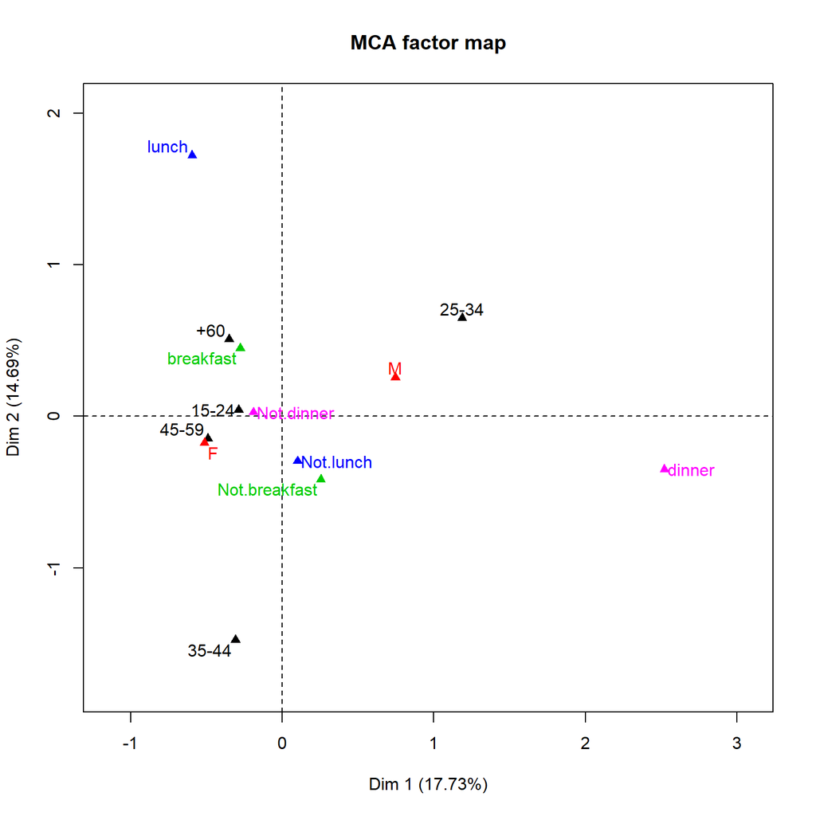

```r
plot(mca, invisible=c("ind"), graph.type = "classic", habillage = "quali")
```

```r
fig.dim = c(8, 8)
```

# Assignment 6

In our last assignment, we shall practice repeated measurement analyses with two data sets. The task was to implement summary methods (Chapter 8 of MABS), using the R codes of Exercise Set 6 PART I with “RATS” data; and linear mixed effects models (Chapter 9 of MABS), using the R codes of Exercise Set 6 with “BPRS” data.

Brief descriptions of the wrangling process is available at my GitHub repository *https://github.com/norppakeitto/IODS-project* data -folder.

```r
BPRSL <- read.csv("BPRSL.csv")
RATSL <- read.csv("RATSL.csv")

library(tidyverse)
BPRSL <- BPRSL %>% mutate(treatment = as.factor(treatment), subject = as.factor(subject))

RATSL <- RATSL %>% mutate(ID = as.factor(ID), Group = as.factor(Group))
```

## Rats

We begin with RATSL, that is a long form data of 16 rats and consecutive weight measurements. The rat’s were put on different diets, and each animal’s body weight (grams) was recorded repeatedly (approximately) weekly over a 9-week period.

```r
str(RATSL)
```

```
## 'data.frame':    176 obs. of  5 variables:
##  $ ID    : Factor w/ 16 levels "1","2","3","4",..: 1 2 3 4 5 6 7 8 9 10 ...
##  $ Group : Factor w/ 3 levels "1","2","3": 1 1 1 1 1 1 1 1 2 2 ...
##  $ WD    : chr  "WD1" "WD1" "WD1" "WD1" ...
##  $ Weight: int  240 225 245 260 255 260 275 245 410 405 ...
##  $ Time  : int  1 1 1 1 1 1 1 1 1 1 ...
```

```r
dim(RATSL)
```

```
## [1] 176   5
```

```r
RATSL%>% summary()
```

```
##        ID      Group       WD                Weight           Time
##  1      : 11   1:88   Length:176         Min.   :225.0   Min.   : 1.00
##  2      : 11   2:44   Class :character   1st Qu.:267.0   1st Qu.:15.00
##  3      : 11   3:44   Mode  :character   Median :344.5   Median :36.00
##  4      : 11                             Mean   :384.5   Mean   :33.55
##  5      : 11                             3rd Qu.:511.2   3rd Qu.:50.00
##  6      : 11                             Max.   :628.0   Max.   :64.00
##  (Other):110
```

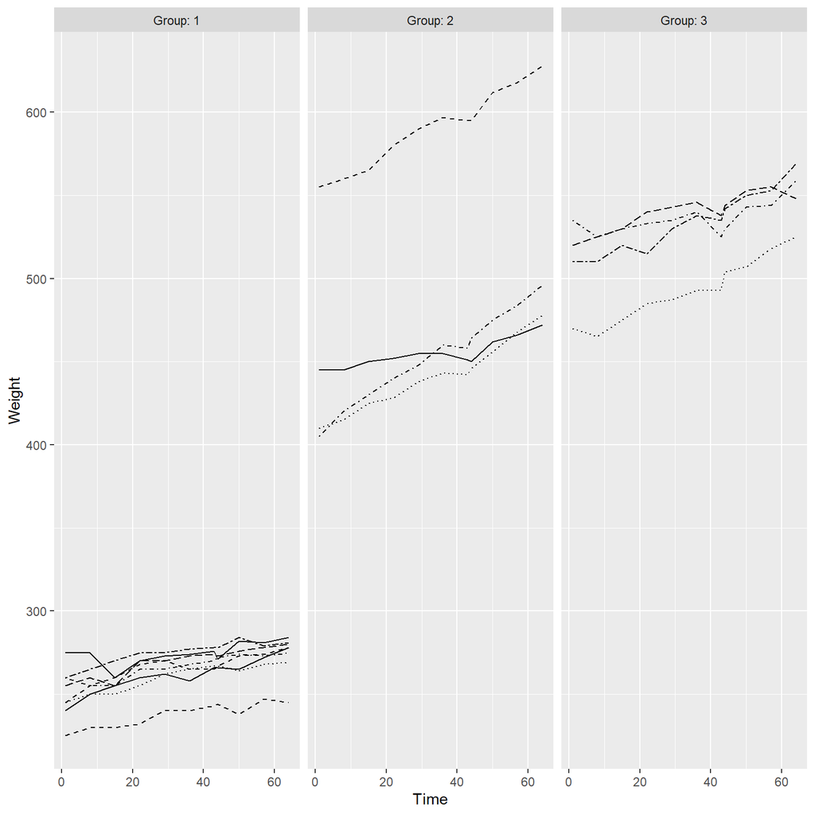

```r
library(ggplot2)

# Individual rat weight values per week. Each group is in its own plot.
ggplot(RATSL, aes(x = Time, y = Weight, linetype = ID)) +
  geom_line() +
  scale_linetype_manual(values = rep(1:10, times=4)) +
  facet_grid(. ~ Group, labeller = label_both) +
  theme(legend.position = "none") +
  scale_y_continuous(limits = c(min(RATSL$Weight), max(RATSL$Weight)))
```

Rats in groups 2 and 3 seem to have greater weight to begin with. Consequently, they also have greater weight in the end. (At this point, I must say, this experiment is not going to give us any trustworthy results regarding diet effects since the rats were clearly not randomized to groups…)

For graphical summary, I’ll use standardized mean weight and standard error of mean.

```r
RATSL <- RATSL %>%
  dplyr::group_by(Time) %>%
  mutate(stdweight = scale(Weight)) %>% ungroup()

library(dplyr)
library(tidyr)

RATSL_std <- RATSL %>%
  dplyr::group_by(Group, Time) %>%
  summarise(mean = mean(Weight), sd = sd(Weight), n= n(), se = sd/sqrt(n)) %>% ungroup()
```

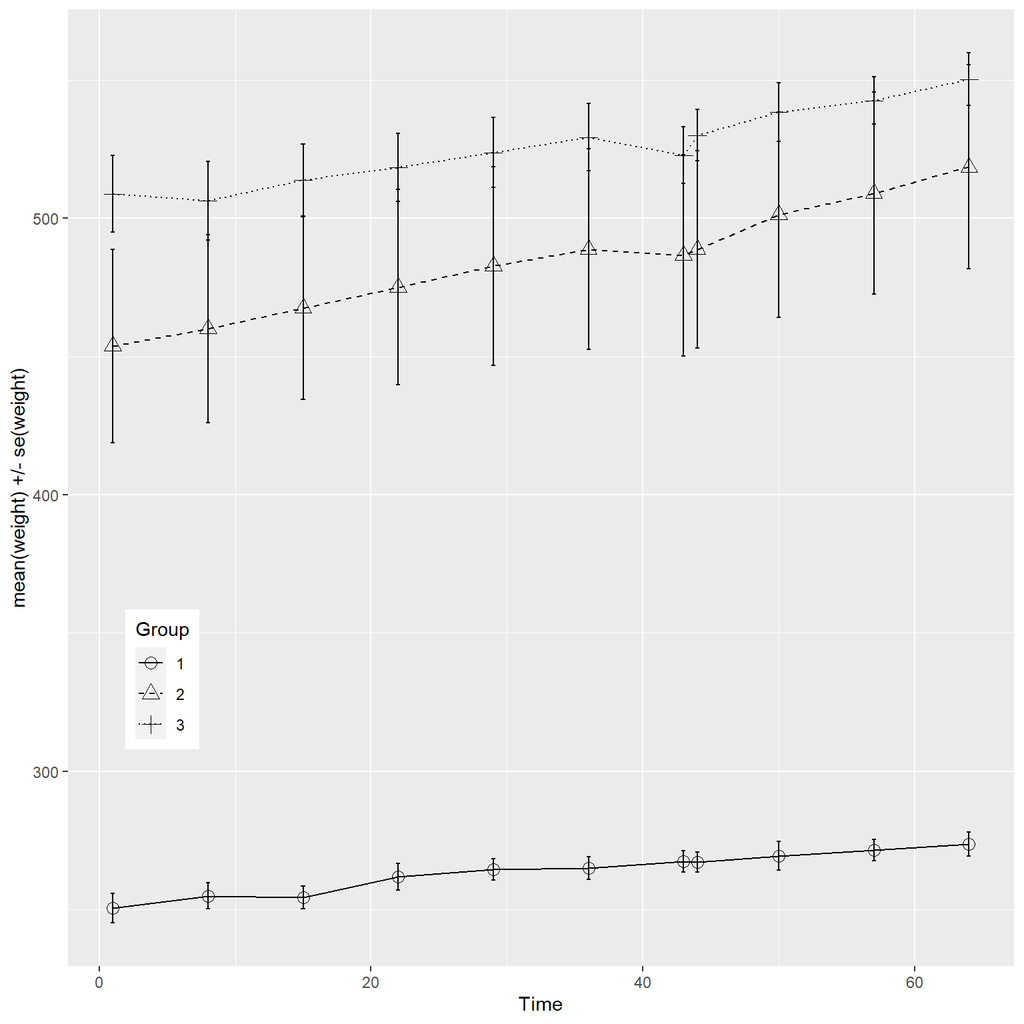

```r
library(ggplot2)
ggplot(RATSL_std, aes(x = Time, y = mean, linetype = Group, shape = Group)) +
  geom_line() +
  scale_linetype_manual(values = c(1,2,3)) +
  geom_point(size=3) +
  scale_shape_manual(values = c(1,2,3)) +
  geom_errorbar(aes(ymin=mean-se, ymax=mean+se, linetype="1"), width=0.3) +
  theme(legend.position = c(0.1,0.3)) +
  scale_y_continuous(name = "mean(weight) +/- se(weight)")
```

We’ll continue with boxplots that compare the total weight gain in each group during the study.

```r
library(dplyr)
library(tidyr)

RATSL <- read.csv("RATSL.csv")
RATSL <- RATSL %>% mutate(ID = as.factor(ID), Group = as.factor(Group))

RATSL <- RATSL %>%
  dplyr::group_by(ID) %>%
  mutate(weightgain=sum(Weight[Time==64]-Weight[Time==1]))%>% ungroup()

glimpse(RATSL)
```

```
## Rows: 176
## Columns: 6
## $ ID         <fct> 1, 2, 3, 4, 5, 6, 7, 8, 9, 10, 11, 12, 13, 14, 15, 16, 1, 2…
## $ Group      <fct> 1, 1, 1, 1, 1, 1, 1, 1, 2, 2, 2, 2, 3, 3, 3, 3, 1, 1, 1, 1,…
## $ WD         <chr> "WD1", "WD1", "WD1", "WD1", "WD1", "WD1", "WD1", "WD1", "WD…
## $ Weight     <int> 240, 225, 245, 260, 255, 260, 275, 245, 410, 405, 445, 555,…
## $ Time       <int> 1, 1, 1, 1, 1, 1, 1, 1, 1, 1, 1, 1, 1, 1, 1, 1, 8, 8, 8, 8,…
## $ weightgain <int> 38, 20, 24, 15, 25, 21, 9, 33, 68, 91, 27, 73, 55, 24, 28, …
```

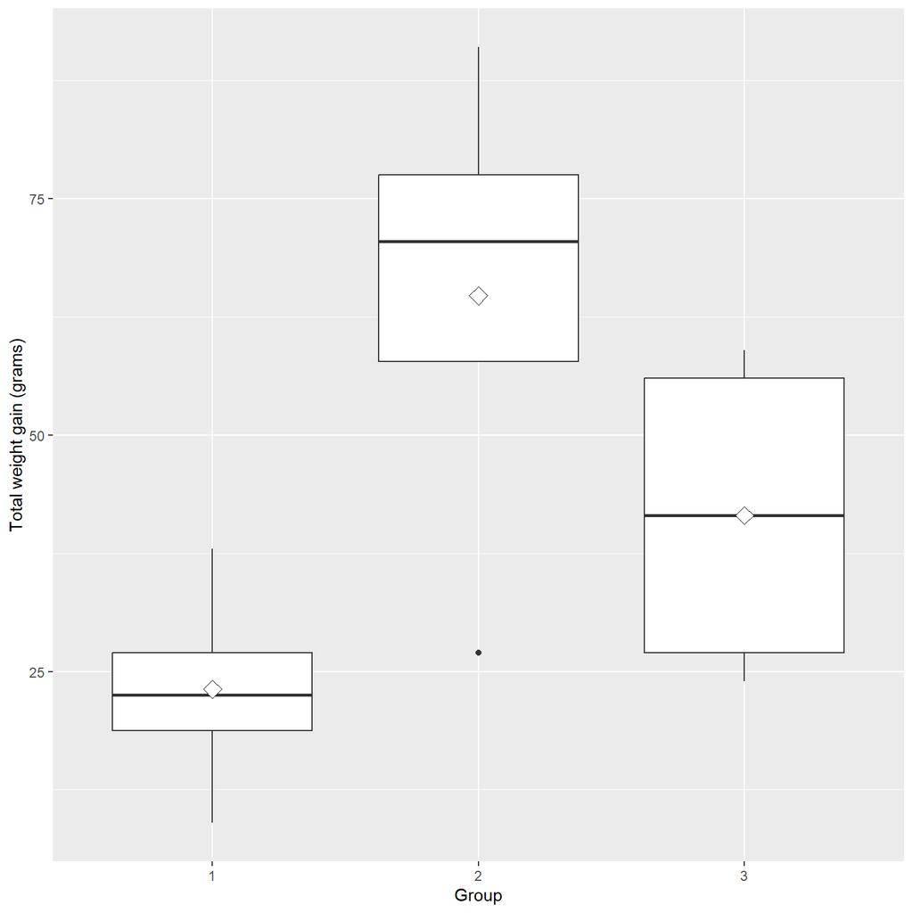

```r
library(ggplot2)
ggplot(RATSL, aes(x = Group, y = weightgain)) +
  geom_boxplot() +
  stat_summary(fun = "mean", geom = "point", shape=23, size=4, fill = "white") +
  scale_y_continuous(name = "Total weight gain (grams)")
```

The greatest overall weightgain has been in group 2, but there is a lot of variation. One rat has gained weight similarly as initially thinner rats from group 1. Since there are only four rats in group 2, and supposing this is not a measurement error, I would not recommend removing this outlier rat from the data.

## BPRS

So, let’s forget about that nonsense rat data and move on. The BPRSL data is a long form data of psychiatric male patients that have been randomly assigned to two treatment groups (20 patients each). The “bprs” are psychiatric evaluation points that have been measured in the beginning (week 0) and weekly untill week 8.

```r
str(BPRSL)
```

```
## 'data.frame':    360 obs. of  5 variables:
##  $ treatment: Factor w/ 2 levels "1","2": 1 1 1 1 1 1 1 1 1 1 ...
##  $ subject  : Factor w/ 20 levels "1","2","3","4",..: 1 2 3 4 5 6 7 8 9 10 ...
##  $ weeks    : chr  "week0" "week0" "week0" "week0" ...
##  $ bprs     : int  42 58 54 55 72 48 71 30 41 57 ...
##  $ week     : int  0 0 0 0 0 0 0 0 0 0 ...
```

```r
dim(BPRSL)
```

```
## [1] 360   5
```

```r
BPRSL%>% summary()
```

```
##  treatment    subject       weeks                bprs            week
##  1:180     1      : 18   Length:360         Min.   :18.00   Min.   :0
##  2:180     2      : 18   Class :character   1st Qu.:27.00   1st Qu.:2
##            3      : 18   Mode  :character   Median :35.00   Median :4
##            4      : 18                      Mean   :37.66   Mean   :4
##            5      : 18                      3rd Qu.:43.00   3rd Qu.:6
##            6      : 18                      Max.   :95.00   Max.   :8
##            (Other):252
```

We’ll start with a plot that shows individual patients’ progress in each treatment group.

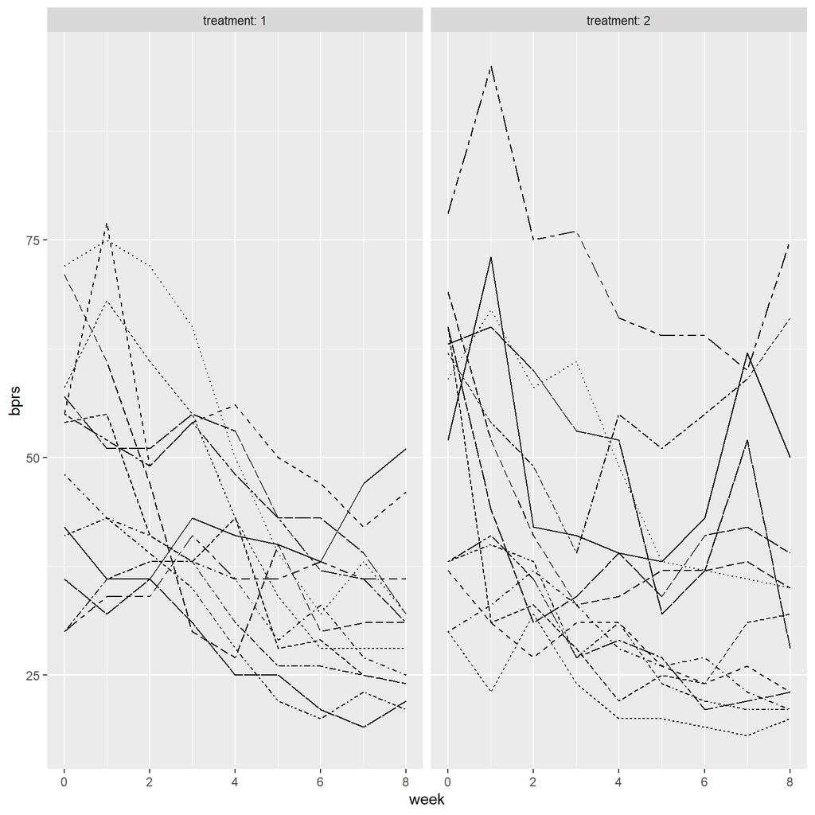

```r
library(dplyr)
library(tidyr)
library(ggplot2)

ggplot(BPRSL, aes(x = week, y = bprs, linetype = subject)) +
  geom_line() +
  facet_grid(. ~ treatment, labeller = label_both) +
  theme(legend.position = "none") +
scale_y_continuous(limits = c(min(BPRSL$bprs), max(BPRSL$bprs)))
```

It is obvious from this plot that the initial bprs points predict the situation at 8 weeks; patients with initially higher points tend to have higher points later. There is one outlier patient in treatment 2 group. Notably, some patients have higher bprs points in week 8 than they did week 0.

Let’s draw a plot that separates the treatment groups.

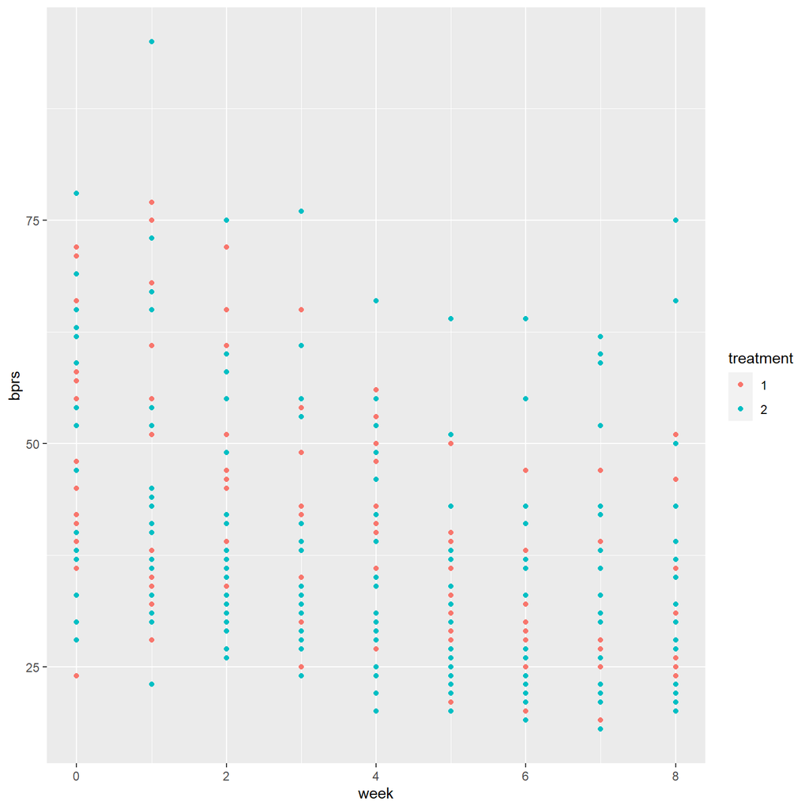

```r
ggplot(data = BPRSL)+geom_point(mapping=aes(x=week, y=bprs, color=treatment))
```

There doesn’t seem to be very much difference in the outcome bprs points at 8 weeks between the treatment groups.